# OEB275R - PhyloAcc exercises - Fall 2022

# 1 Intro

Check out the [terms](https://gwct.github.io/phyloacc/OEB275R/terms.html) and [programs](https://gwct.github.io/phyloacc/OEB275R/programs.html) page on the workshop website if you encounter anything you don’t understand. And there are several relevant papers on the [links](https://gwct.github.io/phyloacc/OEB275R/links.html) page as well!

But please don’t hesitate to ask any questions as well!

# 2 Setup

Today we’ll be analyzing some PhyloAcc results (2,000 conserved non-coding loci from 62 mammals) using RStudio and RMarkdown, which allows you to run chunks of code and display the figures right in RStudio.

To get started, run the two blocks below to setup the Rmarkdown script. The first block (setup) installs and loads the required libraries. The second block (read-files) reads all the data we’re going to be analyzing into data frames.

To run chunks, either click on the green triangle icon in the upper right hand corner of the chunk, or select the chunk by clicking inside of it and then hitting CTRL+SHIFT+ENTER.

```r
install_load <- function (pkg_vec){
  for(pkg in pkg_vec){
    if(!pkg %in% rownames(installed.packages())){
      install.packages(pkg)
    }
    do.call("library", list(pkg))
  }
}
# Function to check for required packages and install and load
# them as necessary

knitr::opts_chunk$set(echo = TRUE, warning = FALSE, message = FALSE)
# RMarkdown options

packages = c("ggplot2", "dplyr", "tidyr", "cowplot", "ggExtra", "stringr", "kableExtra", "viridis", "here", "optparse", "phytools", "rmdformats")
install_load(packages)
# install regular packages

if(!"ggtree" %in% rownames(installed.packages())){
  if (!require("BiocManager", quietly = TRUE))
      install.packages("BiocManager")
  BiocManager::install("ggtree")
}
library("ggtree")
# Install and ggtree separately b/c it's weird
# The packages to load

source(here("scripts", "lib", "design.r"))
source(here("scripts", "lib", "get_tree_info.r"))
# Some custom libraries
```

```r
tree_file = here("data", "mammal.tre")
tree = read.tree(file=tree_file)
tree_to_df_list = treeToDF(tree)
tree_info = tree_to_df_list[["info"]]
# The mammal tree

scf_tree_file = here("data", "phyloacc-scf.tre")
scf_tree = read.tree(file=scf_tree_file)
tree_to_df_list = treeToDF(scf_tree)
scf_tree_info = tree_to_df_list[["info"]]
scf_tree_info = scf_tree_info %>% separate(label, c("tp", "scf", "orig.label"), sep="_", remove=T)
scf_tree_info[scf_tree_info$tp=="<60>",]$orig.label = scf_tree_info[scf_tree_info$tp=="<60>",]$scf
scf_tree_info[scf_tree_info$tp=="<60>",]$scf = NA
scf_tree_info$scf = as.numeric(scf_tree_info$scf)
# The tree with sCF labels

aln_stats_file = here("data", "phyloacc-aln-stats.csv")
aln_stats = read.csv(aln_stats_file, header=T)
# Alignment stats for each locus, including average site concordance factors (sCF)

st_result_file = here("data", "st-test-branches", "results", "elem_lik.txt")
st_results = read.csv(st_result_file, header=T, sep="\t", comment.char="#")
# PhyloAcc results from the species tree run

gt_result_file = here("data", "gt-test-branches", "results", "elem_lik.txt")
gt_results = read.csv(gt_result_file, header=T, sep="\t", comment.char="#")
# PhyloAcc results from the gene tree run
```

# 3 Mammal species tree

So, we’ve run PhyloAcc on our mammal data, specifying marine mammal lineages as targets for M1. PhyloAcc has calculated the probability of M0 (no acceleration), M1 (acceleration on target branches only), and M2 (acceleration on any branch) and now we get to see the results!

This data consists of ~2,000 conserved non-coding regions among 62 mammal species.

Run the chunk below to display the species tree for these mammals as inferred by the team from the UCSC genome browser:

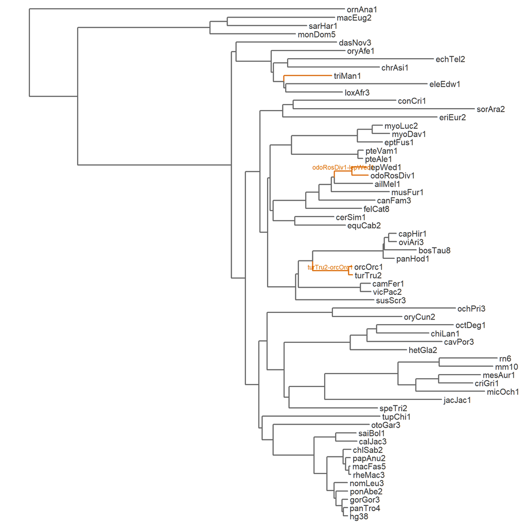

```r
mm_branches = c("turTru2", "orcOrc1", "turTru2-orcOrc1", "odoRosDiv1", "lepWed1", "odoRosDiv1-lepWed1", "triMan1")
tree_info$mm = ifelse(tree_info$label %in% mm_branches, "Y", "N")
# A list of the marine mammal lineages to color and label them them in the tree

mm_tree = ggtree(tree, size=0.8, ladderize=F, aes(color=tree_info$mm)) +
  geom_tiplab(color="#333333", size=4) +
  scale_color_manual(name="Target lineages", values=c("#666666", corecol(numcol=1))) +
  geom_text(aes(x=branch, label=ifelse(tree_info$node.type=="internal" & tree_info$mm=="Y", tree_info$label, '')), size=3, vjust=-0.3, show.legend=F) +
  theme(legend.position="none")
# Render the tree with ggtree

print(mm_tree)
```

```r
# Display the tree
```

In this tree, the marine mammal lineages, which were set as the target lineages for the M1 model in PhyloAcc, are shown in orange.

# 4 PhyloAcc output

So what does the output of PhyloAcc look like? There are several files produced, including matrices of rates and conservation states. Previously the elem_lik.txt file contained the likelihood and Bayes factors for each of the three models for each locus. In the latest version, I’ve tried to summarize a lot of the important data into a single table in this file. We read that file into a data frame above, let’s take a look at its contents here by running the chunk below (note that best.fit.model based on Bayes factor cutoffs of 4):

```r
st_results_display = head(st_results, n=20)
if(interactive()){
  st_results_display %>% kable(row.names=F) %>% kable_styling(bootstrap_options=c("striped", "condended", "responsive"), full_width=F)
}else{
  st_results_display %>% kable(row.names=F) %>% kable_styling(bootstrap_options=c("striped", "condended", "responsive"), full_width=F) %>%
    scroll_box(width = "100%", height = "20vh")
}
```

| phyloacc.id | original.id | best.fit.model | marginal.likelihood.m0 | marginal.likelihood.m1 | marginal.likelihood.m2 | logbf1 | logbf2 | logbf3 | conserved.rate.m0 | accel.rate.m0 | conserved.rate.m1 | accel.rate.m1 | conserved.rate.m2 | accel.rate.m2 | num.accel.m1 | num.accel.m2 | conserved.lineages.m1 | accel.lineages.m1 | conserved.lineages.m2 | accel.lineages.m2 |
| --- | --- | --- | --- | --- | --- | --- | --- | --- | --- | --- | --- | --- | --- | --- | --- | --- | --- | --- | --- | --- |
| 36-0 | chr16-15 | M1 | -1326.2982 | -1321.5055 | -1325.5830 | 4.792632 | 4.0774363 | 0.71520 | 0.1026140 | 1 | 0.0983498 | 0.845306 | 0.0978860 | 0.834896 | 1 | 3 | hg38,panTro4,gorGor3,ponAbe2,nomLeu3,rheMac3,macFas5,papAnu2,chlSab2,calJac3,saiBol1,otoGar3,tupChi1,speTri2,jacJac1,micOch1,criGri1,mesAur1,mm10,rn6,hetGla2,cavPor3,chiLan1,octDeg1,oryCun2,ochPri3,su… | triMan1 | hg38,panTro4,gorGor3,ponAbe2,nomLeu3,rheMac3,macFas5,papAnu2,chlSab2,calJac3,saiBol1,otoGar3,tupChi1,speTri2,jacJac1,micOch1,criGri1,mesAur1,mm10,rn6,hetGla2,cavPor3,chiLan1,oryCun2,ochPri3,susScr3,vi… | octDeg1,myoDav1,triMan1 |
| 36-1 | chr1-144 | M0 | -982.4472 | -975.9869 | -979.2559 | 6.460319 | 3.2689690 | 3.19135 | 0.3458860 | 1 | 0.3293720 | 1.985560 | 0.3159640 | 1.161510 | 2 | 24 | hg38,panTro4,gorGor3,ponAbe2,nomLeu3,rheMac3,macFas5,papAnu2,chlSab2,calJac3,saiBol1,otoGar3,tupChi1,speTri2,jacJac1,micOch1,criGri1,mesAur1,mm10,rn6,hetGla2,cavPor3,chiLan1,octDeg1,oryCun2,ochPri3,su… | lepWed1,triMan1 | hg38,panTro4,gorGor3,ponAbe2,nomLeu3,calJac3,saiBol1,otoGar3,tupChi1,speTri2,micOch1,criGri1,mesAur1,mm10,rn6,hetGla2,cavPor3,chiLan1,octDeg1,oryCun2,ochPri3,vicPac2,camFer1,turTru2,orcOrc1,panHod1,bo… | rheMac3,macFas5,papAnu2,chlSab2,jacJac1,susScr3,ailMel1,odoRosDiv1,lepWed1,pteAle1,sorAra2,conCri1,loxAfr3,eleEdw1,triMan1,echTel2,dasNov3,rheMac3-macFas5,rheMac3-papAnu2,rheMac3-chlSab2,odoRosDiv1-le… |
| 36-2 | chr6-78 | M0 | -2346.8655 | -2343.0277 | -2348.3837 | 3.837776 | 5.3560011 | -1.51820 | 0.1942630 | 1 | 0.1864620 | 0.748741 | 0.1891210 | 0.906939 | 6 | 11 | hg38,panTro4,gorGor3,ponAbe2,nomLeu3,rheMac3,macFas5,papAnu2,chlSab2,calJac3,saiBol1,otoGar3,tupChi1,speTri2,jacJac1,micOch1,criGri1,mesAur1,mm10,rn6,hetGla2,cavPor3,chiLan1,octDeg1,oryCun2,ochPri3,su… | turTru2,orcOrc1,odoRosDiv1,lepWed1,triMan1,turTru2-orcOrc1 | hg38,panTro4,gorGor3,ponAbe2,nomLeu3,rheMac3,macFas5,papAnu2,chlSab2,saiBol1,otoGar3,tupChi1,speTri2,jacJac1,criGri1,mesAur1,mm10,rn6,hetGla2,cavPor3,chiLan1,octDeg1,oryCun2,ochPri3,susScr3,vicPac2,pa… | calJac3,micOch1,camFer1,turTru2,orcOrc1,odoRosDiv1,lepWed1,eriEur2,triMan1,turTru2-orcOrc1,odoRosDiv1-lepWed1 |
| 36-3 | chr1-209 | M2 | -1970.0345 | -1883.5378 | -1885.9881 | 86.496714 | 2.4502372 | 84.04640 | 0.1256870 | 1 | 0.1660690 | 9.238080 | 0.1624570 | 7.519560 | 1 | 2 | hg38,panTro4,gorGor3,ponAbe2,nomLeu3,rheMac3,macFas5,papAnu2,chlSab2,calJac3,saiBol1,otoGar3,tupChi1,speTri2,jacJac1,micOch1,criGri1,mesAur1,mm10,rn6,hetGla2,cavPor3,chiLan1,octDeg1,oryCun2,ochPri3,su… | odoRosDiv1 | hg38,panTro4,gorGor3,ponAbe2,nomLeu3,rheMac3,macFas5,papAnu2,calJac3,saiBol1,otoGar3,tupChi1,speTri2,jacJac1,micOch1,criGri1,mesAur1,mm10,rn6,hetGla2,cavPor3,chiLan1,octDeg1,oryCun2,ochPri3,susScr3,vi… | chlSab2,odoRosDiv1 |
| 36-4 | chr1-105 | M2 | -991.7576 | -986.9233 | -986.4136 | 4.834346 | -0.5096536 | 5.34400 | 0.3297160 | 1 | 0.2985860 | 3.494270 | 0.2672190 | 0.903002 | 1 | 33 | hg38,panTro4,gorGor3,ponAbe2,nomLeu3,rheMac3,macFas5,papAnu2,chlSab2,calJac3,saiBol1,otoGar3,tupChi1,speTri2,mm10,rn6,cavPor3,chiLan1,oryCun2,ochPri3,susScr3,vicPac2,camFer1,orcOrc1,panHod1,bosTau8,ov… | turTru2 | hg38,panTro4,ponAbe2,nomLeu3,calJac3,saiBol1,otoGar3,tupChi1,speTri2,cavPor3,chiLan1,oryCun2,ochPri3,vicPac2,camFer1,orcOrc1,panHod1,equCab2,felCat8,musFur1,ailMel1,odoRosDiv1,pteAle1,pteVam1,eptFus1,… | gorGor3,rheMac3,macFas5,papAnu2,chlSab2,jacJac1,micOch1,criGri1,mesAur1,mm10,rn6,hetGla2,octDeg1,susScr3,turTru2,bosTau8,oviAri3,capHir1,cerSim1,canFam3,lepWed1,eleEdw1,dasNov3,rheMac3-macFas5,rheMac3… |
| 36-5 | chr12-48 | M2 | -1481.1242 | -1475.4064 | -1476.9703 | 5.717843 | 1.5638947 | 4.15390 | 0.2084440 | 1 | 0.1976130 | 1.331380 | 0.1891220 | 1.129320 | 3 | 10 | hg38,panTro4,gorGor3,ponAbe2,nomLeu3,rheMac3,macFas5,papAnu2,chlSab2,calJac3,saiBol1,otoGar3,tupChi1,speTri2,jacJac1,micOch1,criGri1,mesAur1,mm10,rn6,hetGla2,cavPor3,chiLan1,octDeg1,oryCun2,ochPri3,su… | turTru2,orcOrc1,turTru2-orcOrc1 | ponAbe2,nomLeu3,rheMac3,macFas5,papAnu2,chlSab2,calJac3,saiBol1,otoGar3,tupChi1,speTri2,jacJac1,micOch1,criGri1,mesAur1,mm10,rn6,cavPor3,chiLan1,octDeg1,oryCun2,ochPri3,susScr3,vicPac2,panHod1,bosTau8… | hg38,panTro4,gorGor3,hetGla2,camFer1,turTru2,orcOrc1,hg38-panTro4,hg38-gorGor3,turTru2-orcOrc1 |
| 36-6 | chr7-4 | M1 | -1259.2111 | -1229.9954 | -1235.4450 | 29.215708 | 5.4495719 | 23.76610 | 0.3905550 | 1 | 0.3472200 | 7.284040 | 0.3506600 | 6.763850 | 2 | 5 | hg38,panTro4,gorGor3,ponAbe2,nomLeu3,rheMac3,macFas5,papAnu2,chlSab2,calJac3,saiBol1,otoGar3,tupChi1,speTri2,jacJac1,micOch1,criGri1,mesAur1,mm10,rn6,hetGla2,cavPor3,chiLan1,octDeg1,oryCun2,ochPri3,su… | turTru2,orcOrc1 | hg38,panTro4,nomLeu3,rheMac3,macFas5,papAnu2,chlSab2,saiBol1,otoGar3,tupChi1,speTri2,jacJac1,micOch1,criGri1,mesAur1,mm10,rn6,hetGla2,cavPor3,chiLan1,octDeg1,oryCun2,ochPri3,susScr3,vicPac2,camFer1,pa… | gorGor3,ponAbe2,calJac3,turTru2,orcOrc1 |
| 36-7 | chr8-71 | M2 | -979.3341 | -957.1745 | -960.4328 | 22.159579 | 3.2582560 | 18.90132 | 0.1986150 | 1 | 0.2012920 | 8.980730 | 0.2019460 | 8.234850 | 1 | 1 | hg38,panTro4,gorGor3,ponAbe2,nomLeu3,rheMac3,macFas5,papAnu2,chlSab2,calJac3,saiBol1,otoGar3,tupChi1,speTri2,jacJac1,micOch1,criGri1,mesAur1,mm10,rn6,hetGla2,oryCun2,ochPri3,turTru2,panHod1,oviAri3,ca… | orcOrc1 | hg38,panTro4,gorGor3,ponAbe2,nomLeu3,rheMac3,macFas5,papAnu2,chlSab2,calJac3,saiBol1,otoGar3,tupChi1,speTri2,jacJac1,micOch1,criGri1,mesAur1,mm10,rn6,hetGla2,cavPor3,oryCun2,ochPri3,turTru2,panHod1,ov… | orcOrc1 |
| 36-8 | chr20-20 | M1 | -1596.5822 | -1589.7361 | -1595.6859 | 6.846114 | 5.9497939 | 0.89630 | 0.1626530 | 1 | 0.1515590 | 0.822268 | 0.1505990 | 0.761306 | 6 | 16 | hg38,panTro4,gorGor3,ponAbe2,nomLeu3,rheMac3,macFas5,papAnu2,chlSab2,calJac3,saiBol1,otoGar3,tupChi1,speTri2,jacJac1,micOch1,criGri1,mesAur1,mm10,rn6,hetGla2,cavPor3,chiLan1,octDeg1,oryCun2,ochPri3,su… | turTru2,orcOrc1,odoRosDiv1,lepWed1,turTru2-orcOrc1,odoRosDiv1-lepWed1 | hg38,panTro4,gorGor3,ponAbe2,nomLeu3,rheMac3,macFas5,papAnu2,chlSab2,otoGar3,tupChi1,speTri2,jacJac1,micOch1,criGri1,mesAur1,mm10,rn6,hetGla2,cavPor3,chiLan1,octDeg1,oryCun2,ochPri3,susScr3,vicPac2,pa… | calJac3,saiBol1,camFer1,turTru2,orcOrc1,equCab2,odoRosDiv1,lepWed1,myoDav1,myoLuc2,triMan1,echTel2,calJac3-saiBol1,turTru2-orcOrc1,odoRosDiv1-lepWed1,myoDav1-myoLuc2 |
| 36-9 | chr2-252 | M1 | -1531.2725 | -1513.4395 | -1517.4706 | 17.832935 | 4.0310545 | 13.80190 | 0.2572540 | 1 | 0.2457870 | 2.246370 | 0.2435700 | 2.123800 | 3 | 19 | hg38,panTro4,gorGor3,ponAbe2,nomLeu3,rheMac3,macFas5,papAnu2,chlSab2,calJac3,saiBol1,otoGar3,tupChi1,speTri2,jacJac1,micOch1,criGri1,mesAur1,mm10,rn6,hetGla2,cavPor3,chiLan1,octDeg1,oryCun2,ochPri3,su… | turTru2,orcOrc1,turTru2-orcOrc1 | hg38,panTro4,gorGor3,ponAbe2,saiBol1,otoGar3,tupChi1,speTri2,jacJac1,micOch1,criGri1,mesAur1,mm10,rn6,hetGla2,cavPor3,chiLan1,octDeg1,oryCun2,ochPri3,susScr3,camFer1,panHod1,bosTau8,equCab2,cerSim1,fe… | nomLeu3,rheMac3,macFas5,papAnu2,chlSab2,calJac3,vicPac2,turTru2,orcOrc1,oviAri3,capHir1,lepWed1,oryAfe1,dasNov3,rheMac3-macFas5,rheMac3-papAnu2,rheMac3-chlSab2,turTru2-orcOrc1,oviAri3-capHir1 |
| 36-10 | chr11-60 | M2 | -776.7608 | -769.4235 | -772.4477 | 7.337259 | 3.0241156 | 4.31314 | 0.1320120 | 1 | 0.1212540 | 1.246030 | 0.1189370 | 1.219990 | 4 | 13 | hg38,panTro4,gorGor3,ponAbe2,nomLeu3,rheMac3,macFas5,papAnu2,chlSab2,calJac3,saiBol1,otoGar3,tupChi1,speTri2,jacJac1,micOch1,criGri1,mesAur1,mm10,rn6,hetGla2,cavPor3,chiLan1,octDeg1,oryCun2,ochPri3,su… | turTru2,orcOrc1,lepWed1,turTru2-orcOrc1 | ponAbe2,nomLeu3,rheMac3,macFas5,papAnu2,chlSab2,calJac3,saiBol1,otoGar3,tupChi1,speTri2,jacJac1,micOch1,criGri1,mesAur1,mm10,rn6,hetGla2,cavPor3,chiLan1,octDeg1,oryCun2,ochPri3,susScr3,vicPac2,camFer1… | hg38,panTro4,gorGor3,turTru2,orcOrc1,panHod1,lepWed1,myoLuc2,triMan1,chrAsi1,hg38-panTro4,hg38-gorGor3,turTru2-orcOrc1 |
| 36-11 | chr12-2 | M1 | -948.8320 | -943.3382 | -948.6054 | 5.493808 | 5.2671936 | 0.22661 | 0.1993460 | 1 | 0.1836580 | 1.107190 | 0.1773580 | 0.885103 | 4 | 19 | hg38,panTro4,gorGor3,ponAbe2,nomLeu3,rheMac3,macFas5,papAnu2,chlSab2,calJac3,saiBol1,otoGar3,tupChi1,speTri2,jacJac1,micOch1,criGri1,mesAur1,mm10,rn6,hetGla2,cavPor3,chiLan1,octDeg1,oryCun2,ochPri3,su… | turTru2,orcOrc1,triMan1,turTru2-orcOrc1 | hg38,panTro4,gorGor3,rheMac3,macFas5,papAnu2,chlSab2,calJac3,otoGar3,tupChi1,speTri2,jacJac1,micOch1,criGri1,mm10,rn6,cavPor3,chiLan1,octDeg1,oryCun2,ochPri3,susScr3,camFer1,panHod1,bosTau8,oviAri3,ca… | ponAbe2,nomLeu3,saiBol1,mesAur1,hetGla2,vicPac2,turTru2,orcOrc1,equCab2,cerSim1,odoRosDiv1,lepWed1,eriEur2,loxAfr3,triMan1,oryAfe1,turTru2-orcOrc1,equCab2-cerSim1,odoRosDiv1-lepWed1 |
| 36-12 | chr17-66 | M2 | -904.0968 | -888.5138 | -892.4099 | 15.582976 | 3.8961053 | 11.68687 | 0.0750202 | 1 | 0.0703132 | 3.348060 | 0.0716844 | 3.330140 | 1 | 3 | hg38,panTro4,gorGor3,ponAbe2,nomLeu3,rheMac3,macFas5,papAnu2,chlSab2,calJac3,saiBol1,otoGar3,tupChi1,speTri2,jacJac1,micOch1,criGri1,mesAur1,mm10,rn6,hetGla2,cavPor3,chiLan1,octDeg1,oryCun2,ochPri3,su… | orcOrc1 | hg38,panTro4,gorGor3,ponAbe2,nomLeu3,rheMac3,papAnu2,chlSab2,calJac3,saiBol1,otoGar3,tupChi1,speTri2,jacJac1,micOch1,criGri1,mesAur1,mm10,rn6,hetGla2,cavPor3,chiLan1,octDeg1,oryCun2,ochPri3,susScr3,vi… | macFas5,orcOrc1,pteAle1 |
| 36-13 | chr9-32 | M2 | -982.3634 | -953.5758 | -956.1851 | 28.787659 | 2.6093492 | 26.17831 | 0.1811380 | 1 | 0.1962960 | 5.872460 | 0.2125360 | 5.076660 | 1 | 2 | hg38,panTro4,gorGor3,nomLeu3,rheMac3,macFas5,papAnu2,chlSab2,calJac3,otoGar3,tupChi1,speTri2,micOch1,criGri1,mesAur1,mm10,rn6,susScr3,vicPac2,camFer1,turTru2,orcOrc1,panHod1,bosTau8,oviAri3,capHir1,eq… | odoRosDiv1 | hg38,panTro4,gorGor3,nomLeu3,rheMac3,macFas5,papAnu2,chlSab2,calJac3,otoGar3,tupChi1,speTri2,micOch1,criGri1,mesAur1,mm10,rn6,oryCun2,susScr3,vicPac2,camFer1,turTru2,orcOrc1,panHod1,bosTau8,oviAri3,ca… | odoRosDiv1,pteAle1 |
| 36-14 | chr9-89 | M0 | -709.6719 | -704.4734 | -708.0342 | 5.198434 | 3.5607672 | 1.63766 | 0.2767060 | 1 | 0.2898970 | 2.255710 | 0.2894120 | 1.780870 | 3 | 6 | hg38,panTro4,gorGor3,ponAbe2,rheMac3,macFas5,papAnu2,chlSab2,calJac3,saiBol1,tupChi1,speTri2,jacJac1,micOch1,criGri1,mesAur1,mm10,rn6,hetGla2,cavPor3,chiLan1,octDeg1,oryCun2,ochPri3,susScr3,vicPac2,ca… | turTru2,orcOrc1,turTru2-orcOrc1 | hg38,panTro4,gorGor3,ponAbe2,nomLeu3,rheMac3,macFas5,papAnu2,chlSab2,calJac3,saiBol1,tupChi1,speTri2,jacJac1,micOch1,criGri1,mesAur1,mm10,rn6,hetGla2,cavPor3,chiLan1,octDeg1,oryCun2,ochPri3,susScr3,vi… | camFer1,turTru2,orcOrc1,pteAle1,myoDav1,turTru2-orcOrc1 |
| 36-15 | chr2-235 | M1 | -963.4473 | -955.5262 | -959.7141 | 7.921029 | 4.1878974 | 3.73313 | 0.3854920 | 1 | 0.3627860 | 2.390000 | 0.3642280 | 2.320220 | 3 | 27 | hg38,panTro4,gorGor3,ponAbe2,nomLeu3,rheMac3,macFas5,papAnu2,chlSab2,calJac3,saiBol1,otoGar3,tupChi1,speTri2,jacJac1,micOch1,criGri1,mesAur1,mm10,rn6,hetGla2,cavPor3,chiLan1,octDeg1,oryCun2,ochPri3,su… | turTru2,orcOrc1,turTru2-orcOrc1 | panTro4,gorGor3,ponAbe2,nomLeu3,rheMac3,macFas5,papAnu2,chlSab2,calJac3,saiBol1,tupChi1,speTri2,jacJac1,criGri1,mesAur1,hetGla2,susScr3,vicPac2,camFer1,cerSim1,felCat8,canFam3,musFur1,ailMel1,odoRosDi… | hg38,otoGar3,micOch1,mm10,rn6,cavPor3,chiLan1,octDeg1,oryCun2,ochPri3,turTru2,orcOrc1,panHod1,bosTau8,oviAri3,capHir1,equCab2,chrAsi1,mm10-rn6,chiLan1-octDeg1,cavPor3-chiLan1,oryCun2-ochPri3,turTru2-o… |
| 36-16 | chr1-206 | M0 | -1003.8347 | -997.3902 | -1001.1247 | 6.444510 | 3.7344996 | 2.71000 | 0.3062970 | 1 | 0.2998700 | 3.553970 | 0.2917090 | 3.078050 | 1 | 31 | hg38,panTro4,gorGor3,ponAbe2,nomLeu3,rheMac3,macFas5,papAnu2,chlSab2,calJac3,saiBol1,otoGar3,tupChi1,speTri2,jacJac1,micOch1,criGri1,mesAur1,mm10,rn6,hetGla2,cavPor3,chiLan1,octDeg1,oryCun2,ochPri3,su… | orcOrc1 | ponAbe2,nomLeu3,rheMac3,macFas5,papAnu2,chlSab2,otoGar3,tupChi1,speTri2,jacJac1,mm10,rn6,hetGla2,chiLan1,octDeg1,oryCun2,ochPri3,susScr3,vicPac2,camFer1,turTru2,equCab2,cerSim1,felCat8,canFam3,musFur1… | hg38,panTro4,gorGor3,calJac3,saiBol1,micOch1,criGri1,mesAur1,cavPor3,orcOrc1,panHod1,bosTau8,oviAri3,capHir1,pteAle1,pteVam1,eptFus1,myoDav1,myoLuc2,dasNov3,hg38-panTro4,hg38-gorGor3,criGri1-mesAur1,m… |
| 36-17 | chr4-36 | M1 | -659.3445 | -652.3131 | -657.5236 | 7.031387 | 5.2105778 | 1.82081 | 0.2648370 | 1 | 0.2468820 | 2.327590 | 0.2275700 | 1.438120 | 2 | 18 | hg38,panTro4,gorGor3,ponAbe2,nomLeu3,rheMac3,macFas5,papAnu2,chlSab2,calJac3,saiBol1,otoGar3,tupChi1,speTri2,jacJac1,micOch1,criGri1,mesAur1,mm10,rn6,hetGla2,cavPor3,chiLan1,octDeg1,oryCun2,ochPri3,su… | turTru2,orcOrc1 | hg38,panTro4,gorGor3,nomLeu3,rheMac3,papAnu2,chlSab2,calJac3,saiBol1,otoGar3,speTri2,jacJac1,micOch1,mm10,rn6,hetGla2,cavPor3,chiLan1,octDeg1,ochPri3,susScr3,panHod1,bosTau8,oviAri3,capHir1,cerSim1,fe… | ponAbe2,macFas5,tupChi1,criGri1,mesAur1,oryCun2,vicPac2,camFer1,turTru2,orcOrc1,equCab2,eptFus1,myoDav1,loxAfr3,triMan1,criGri1-mesAur1,vicPac2-camFer1,turTru2-orcOrc1 |
| 36-18 | chr2-94 | M1 | -2881.3677 | -2871.6911 | -2876.6789 | 9.676625 | 4.9878552 | 4.68880 | 0.0632685 | 1 | 0.0595369 | 0.645636 | 0.0595072 | 0.643397 | 3 | 5 | hg38,panTro4,gorGor3,ponAbe2,nomLeu3,rheMac3,macFas5,papAnu2,chlSab2,calJac3,saiBol1,otoGar3,tupChi1,speTri2,jacJac1,micOch1,criGri1,mesAur1,mm10,rn6,hetGla2,cavPor3,chiLan1,octDeg1,oryCun2,ochPri3,su… | turTru2,orcOrc1,triMan1 | hg38,ponAbe2,nomLeu3,rheMac3,macFas5,papAnu2,chlSab2,calJac3,saiBol1,otoGar3,tupChi1,speTri2,jacJac1,micOch1,criGri1,mesAur1,mm10,rn6,hetGla2,cavPor3,chiLan1,octDeg1,oryCun2,ochPri3,susScr3,vicPac2,or… | panTro4,gorGor3,camFer1,turTru2,triMan1 |
| 36-19 | chr3-102 | M1 | -1464.8553 | -1441.6867 | -1446.0325 | 23.168557 | 4.3457902 | 18.82280 | 0.2284440 | 1 | 0.2143330 | 3.269380 | 0.2130320 | 3.239000 | 3 | 14 | hg38,panTro4,gorGor3,ponAbe2,nomLeu3,rheMac3,macFas5,papAnu2,chlSab2,calJac3,saiBol1,otoGar3,tupChi1,speTri2,jacJac1,micOch1,criGri1,mesAur1,mm10,rn6,hetGla2,cavPor3,chiLan1,octDeg1,oryCun2,ochPri3,su… | turTru2,orcOrc1,odoRosDiv1 | hg38,panTro4,ponAbe2,nomLeu3,rheMac3,macFas5,papAnu2,chlSab2,calJac3,saiBol1,otoGar3,tupChi1,micOch1,criGri1,mm10,rn6,hetGla2,chiLan1,octDeg1,oryCun2,ochPri3,susScr3,vicPac2,camFer1,panHod1,bosTau8,ov… | gorGor3,speTri2,jacJac1,mesAur1,cavPor3,turTru2,orcOrc1,equCab2,odoRosDiv1,loxAfr3,eleEdw1,triMan1,loxAfr3-eleEdw1,loxAfr3-triMan1 |

```r
# Subset the table and display
```

We can also summarize some interesting statistics about this table with the following chunk:

```r
st_results_summary = data.frame(
  "num.m0" = nrow(subset(st_results, best.fit.model == "M0")),
  "num.m1" = nrow(subset(st_results, best.fit.model == "M1")),
  "num.m2" = nrow(subset(st_results, best.fit.model == "M2")),
  'avg.accel.lineages.m2' = mean(st_results$num.accel.m2)
)

st_results_summary %>% kable(row.names=F) %>% kable_styling(bootstrap_options=c("striped", "condended", "responsive"), full_width=F)
```

| num.m0 | num.m1 | num.m2 | avg.accel.lineages.m2 |
| --- | --- | --- | --- |
| 650 | 784 | 595 | 13.79004 |

# 5 Bayes Factors

So, the measure of support we’re using when comparing models is the Bayes factor. A Bayes factor is simply a ratio of the marginal probabilities of two models. If the Bayes factor is skewed enough away from 1, it may indicate support for one model over the other.

For example, if we want to know if the model that allows accelerated rates on the target lineages (M1) fits the data better than the model that does not allow accelerated rates on any branch (M0), we would calculate:

$$BF1 = \frac{P(Y | M1)}{P(Y | M0)}$$

Where $Y$ is the data (aligned sequences) and $M*$ is the model. As you can see, this is BF1 and is calculated in the main output table. We can also compare the model that allows acclerated rates to be fit to only the target lineages (M1) to a model that allows accelerated rates on any lineage (M2):

$$BF2 = \frac{P(Y | M1)}{P(Y | M2)}$$

This is BF2 and if it is above 1 it indicates more support for M1 than M2 given the data.

If both BF1 and BF2 are high enough (above some threshold or cutoff), then we would say that M1 best fits the data and these would be the loci that likely have accelerated substitution rates exclusively in our target lineages.

## 5.1 Distributions

Well, what does this look like? What are the distributions of BF1 and BF2 in our data, and how many loci do we find fit M1 best using BF cutoffs of 4? Run the chunk below to display the distributions:

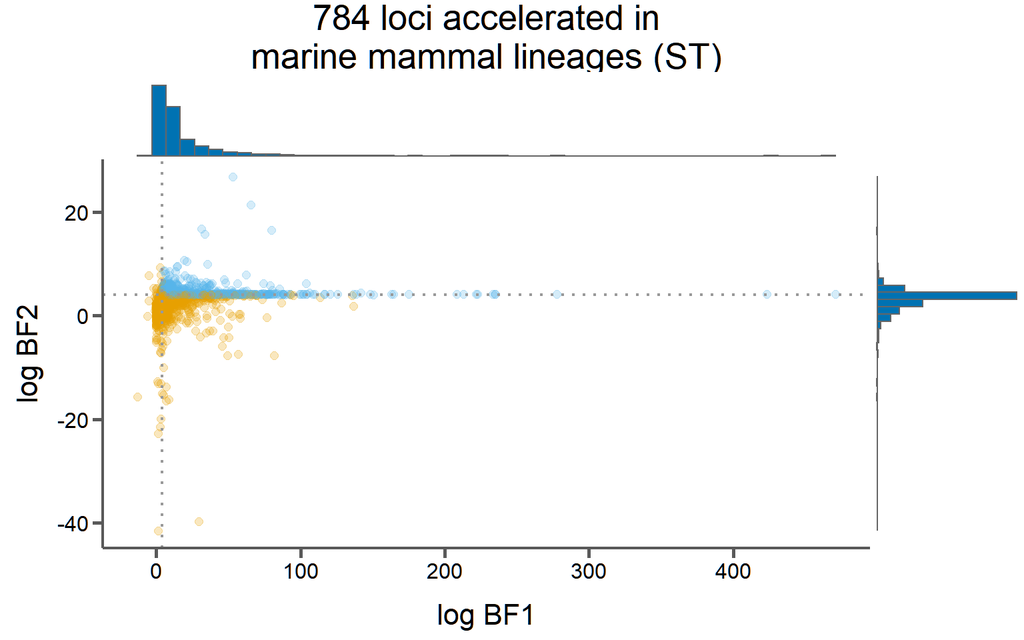

```r
logbf1_cutoff = 4
logbf2_cutoff = 4
# Bayes factor cutoffs
# If you want, change these values and re-run the block to see how it affects the results

st_results$target.acc = ifelse(st_results$logbf1 > logbf1_cutoff & st_results$logbf2 > logbf2_cutoff, "Y", "N")
# Label loci with BF1 > 4 and BF2 > 4, this is equivalent to selecting loci
# with "M1" in the best.fit.model column

num_m1 = nrow(subset(st_results, target.acc=="Y"))
# Count the number of M1 loci

bf_spread_st = ggplot(st_results, aes(x=logbf1, y=logbf2, color=target.acc)) +
  geom_point(size=2, alpha=0.25) +
  geom_vline(xintercept=logbf1_cutoff, size=0.75, linetype="dotted", color="#999999") +
  geom_hline(yintercept=logbf2_cutoff, size=0.75, linetype="dotted", color="#999999") +
  ggtitle(paste(num_m1, " loci accelerated in\nmarine mammal lineages (ST)", sep="")) +
  xlab("log BF1") +
  ylab("log BF2") +
  scale_color_manual(values=corecol(pal="wilke", numcol=2)) +
  bartheme() +
  theme(legend.position="none")
bf_spread_st = ggExtra::ggMarginal(bf_spread_st, type="histogram", bins=50, fill=corecol(pal="wilke", numcol=1, offset=4), color="#666666")
# Render the BF figure with ggplot

print(bf_spread_st)
```

```r
# Display the figure
```

On the x-axis we have the distribution of BF1, which compares M1 to M0. Dots further on the left show more support for M0 while dots to the right show more support for M1. The y-axis shows BF2. Dots towards the top show more support for M1 and dots towards the bottom show support for M2. We also show the distributions of each BF on the opposite axis and place lines at our cutoffs for each BF. Any locus above both the BF1 and BF2 cutoffs are shown in blue. These are the ones we would consider to be accelerated in marine mammal lineages.

With these cutoffs, we count 784 out of our 2000 loci being accelerated for marine mammals. That is a lot, but there are a couple of important things to remember:

1. This is NOT a random sampling of loci. This sample includes many of the loci originally found to be accelerated in marine mammals and the total dataset has over 200,000 loci.
2. We are still working with loci run with the species tree method, so phylogenetic discordance has not been accounted for.

# 6 Substitution rates

So what do the different models look like in terms of substitution rates? Below we’ll take a look at rates represented as branch lengths on the species tree, so longer branches mean higher substitution rates. We’ll look at two loci: one where M1 best fits the data and one where M2 best fits the data. For the locus that best fits M1, we’ll look at both the M1 and M2 fits to get an intuition for what PhyloAcc is doing. Run the block below to generate the trees:

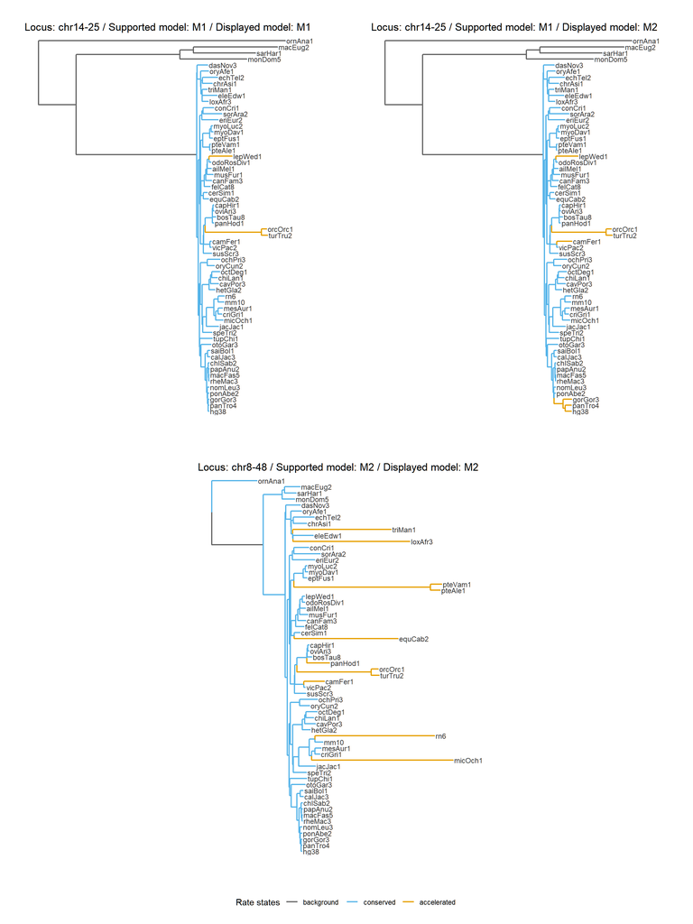

```r
#st_results_m1 = subset(st_results, best.fit.model=="M1")
#m1_locus = sample_n(st_results_m1, 1)
# This randomly selects an M1 locus

m1_locus = subset(st_results, phyloacc.id=="68-5")
# Select an M1 locus as an example. Other good ones are: 68-5, 48-1, 3-24, 73-15

#st_results_m2 = subset(st_results, best.fit.model=="M2")
#m2_locus = sample_n(st_results_m2, 1)
# This randomly selects an M2 locus

m2_locus = subset(st_results, phyloacc.id=="56-13")
# Select an M1 locus as an example. Other good ones are: 3-24, 3-5, 56-13

con_m1_m1 = strsplit(m1_locus$conserved.lineages.m1, split=",")[[1]]
acc_m1_m1 = strsplit(m1_locus$accel.lineages.m1, split=",")[[1]]
con_m1_m2 = strsplit(m1_locus$conserved.lineages.m2, split=",")[[1]]
acc_m1_m2 = strsplit(m1_locus$accel.lineages.m2, split=",")[[1]]
con_m2_m2 = strsplit(m2_locus$conserved.lineages.m2, split=",")[[1]]
acc_m2_m2 = strsplit(m2_locus$accel.lineages.m2, split=",")[[1]]
# Split the lineages in each state for both M1 and M2 into vectors

tree_info$m1m1.state = "background"
tree_info[tree_info$label %in% acc_m1_m1,]$m1m1.state = "accelerated"
tree_info[tree_info$label %in% con_m1_m1,]$m1m1.state = "conserved"
# M1 LOCUS: Label each branch in the tree as background, accelerated, or conserved for M1

tree_info$m1m2.state = "background"
tree_info[tree_info$label %in% acc_m1_m2,]$m1m2.state = "accelerated"
tree_info[tree_info$label %in% con_m1_m2,]$m1m2.state = "conserved"
# M1 LOCUS:  Label each branch in the tree as background, accelerated, or conserved for M2

tree_info$m2m2.state = "background"
tree_info[tree_info$label %in% acc_m2_m2,]$m2m2.state = "accelerated"
tree_info[tree_info$label %in% con_m2_m2,]$m2m2.state = "conserved"
# M2 LOCUS:  Label each branch in the tree as background, accelerated, or conserved for M2

tree_info$m1m1.bl = tree_info$branch.length
tree_info[tree_info$label %in% con_m1_m1,]$m1m1.bl = tree_info[tree_info$label %in% con_m1_m1,]$m1m1.bl * m1_locus$conserved.rate.m1
tree_info[tree_info$label %in% acc_m1_m1,]$m1m1.bl = tree_info[tree_info$label %in% acc_m1_m1,]$m1m1.bl * m1_locus$accel.rate.m1
# M1 LOCUS:  Adjust branch lengths based on the substitution rates in M1

tree_info$m1m2.bl = tree_info$branch.length
tree_info[tree_info$label %in% con_m1_m2,]$m1m2.bl = tree_info[tree_info$label %in% con_m1_m2,]$m1m2.bl * m1_locus$conserved.rate.m2
tree_info[tree_info$label %in% acc_m1_m2,]$m1m2.bl = tree_info[tree_info$label %in% acc_m1_m2,]$m1m2.bl * m1_locus$accel.rate.m2
# M1 LOCUS:  Adjust branch lengths based on the substitution rates in M2

tree_info$m2m2.bl = tree_info$branch.length
tree_info[tree_info$label %in% con_m2_m2,]$m2m2.bl = tree_info[tree_info$label %in% con_m2_m2,]$m2m2.bl * m1_locus$conserved.rate.m2
tree_info[tree_info$label %in% acc_m2_m2,]$m2m2.bl = tree_info[tree_info$label %in% acc_m2_m2,]$m2m2.bl * m1_locus$accel.rate.m2
# M2 LOCUS:  Adjust branch lengths based on the substitution rates in M2

m1_m1_tree = tree
m1_m2_tree = tree
m2_m2_tree = tree
# Copy the tree here since we're editing it

for(i in 1:length(tree$edge.length)){
  cur_len = tree$edge.length[i]
  cur_len = format(round(cur_len, 8), nsmall=8)
  # Get the original length for this branch and convert it to a rounded string

  if(!tree_info[format(round(tree_info$branch.length,8), nsmall=8)==cur_len,]$m1m1.state == "background"){
    m1_m1_tree$edge.length[i] = tree_info[format(round(tree_info$branch.length,8), nsmall=8)==cur_len,]$m1m1.bl
  }
  # M1 LOCUS: If this branch is not in the background state in M1, adjust the branch length here

  if(!tree_info[format(round(tree_info$branch.length,8), nsmall=8)==cur_len,]$m1m2.state == "background"){
    m1_m2_tree$edge.length[i] = tree_info[format(round(tree_info$branch.length,8), nsmall=8)==cur_len,]$m1m2.bl
  }
  # M1 LOCUS: If this branch is not in the background state in M2, adjust the branch length here

  if(!tree_info[format(round(tree_info$branch.length,8), nsmall=8)==cur_len,]$m2m2.state == "background"){
    m2_m2_tree$edge.length[i] = tree_info[format(round(tree_info$branch.length,8), nsmall=8)==cur_len,]$m2m2.bl
  }
  # M2 LOCUS: If this branch is not in the background state in M2, adjust the branch length here
}
# Loop over every branch in the tree and adjust the branch length based on the state in the model

####################

cols = c("background"="#666666", "conserved"=corecol(numcol=1, pal="wilke", offset=1), "accelerated"=corecol(numcol=1, pal="wilke"))
# Set colors for conservation states

cur_title = paste("Locus: ", m1_locus$original.id, " / Supported model: M1 / Displayed model: M1", sep="")
xmax = max(nodeHeights(m1_m1_tree)) + sd(nodeHeights(m1_m1_tree))
m1m1_tree_fig = ggtree(m1_m1_tree, size=0.8, ladderize=F, aes(color=tree_info$m1m1.state)) +
  geom_tiplab(color="#333333", size=3.2) +
  xlim(0, xmax) +
  scale_color_manual(name="Rate states", values=cols) +
  #geom_text(aes(x=branch, label=ifelse(tree_info$node.type=="internal" & tree_info$mm=="Y", tree_info$label, '')), size=3, vjust=-0.3, show.legend=F) +
  ggtitle(cur_title) +
  theme(legend.position="bottom",
        plot.margin=unit(c(1,1,1,1), "cm"))
# M1 locus M1 model tree

cur_title = paste("Locus: ", m1_locus$original.id, " / Supported model: M1 / Displayed model: M2", sep="")
xmax = max(nodeHeights(m1_m2_tree)) + sd(nodeHeights(m1_m2_tree))
m1m2_tree_fig = ggtree(m1_m2_tree, size=0.8, ladderize=F, aes(color=tree_info$m1m2.state)) +
  geom_tiplab(color="#333333", size=3.2) +
  xlim(0, xmax) +
  scale_color_manual(name="Rate states", values=cols) +
  #geom_text(aes(x=branch, label=ifelse(tree_info$node.type=="internal" & tree_info$mm=="Y", tree_info$label, '')), size=3, vjust=-0.3, show.legend=F) +
  ggtitle(cur_title) +
  theme(legend.position="bottom",
        plot.margin=unit(c(1,1,1,1), "cm"))
# M1 locus M2 model tree

cur_title = paste("Locus: ", m2_locus$original.id, " / Supported model: M2 / Displayed model: M2", sep="")
xmax = max(nodeHeights(m2_m2_tree)) + sd(nodeHeights(m2_m2_tree))
m2m2_tree_fig = ggtree(m2_m2_tree, size=0.8, ladderize=F, aes(color=tree_info$m2m2.state)) +
  geom_tiplab(color="#333333", size=3.2) +
  xlim(0, xmax) +
  scale_color_manual(name="Rate states", values=cols) +
  #geom_text(aes(x=branch, label=ifelse(tree_info$node.type=="internal" & tree_info$mm=="Y", tree_info$label, '')), size=3, vjust=-0.3, show.legend=F) +
  ggtitle(cur_title) +
  theme(legend.position="bottom",
        plot.margin=unit(c(1,1,1,1), "cm"))
# M2 locus M2 model tree

tree_legend = get_legend(m1m1_tree_fig)
# Get the legend from one fig

m1_tree_fig = plot_grid(m1m1_tree_fig + theme(legend.position="none"),
                     m1m2_tree_fig + theme(legend.position="none"),
                     ncol=2)
# Combine the M1 locus trees into a single row, removing individual legends

m2_tree_fig = plot_grid(NULL, m2m2_tree_fig + theme(legend.position="none"), NULL, ncol=3, rel_widths=c(0.5,1,0.5))
# Set a row with some padding for the M2 locus and remove its legend

tree_fig = plot_grid(m1_tree_fig, m2_tree_fig, tree_legend, nrow=3, rel_heights=c(1,1,0.1))
# Combine the M1 locus row, M2 locus row, and a single legend

print(tree_fig)
```

```r
# Display the figure
```

Below we have an locus that best fits M2, free acceleration throughout the tree. Here you see that some of the marine mammal lineages are accelerated, but so are many others. Given that M2 best fits this locus we probably wouldn’t think it is involved in aquatic lifestyles for mammals.

# 7 Bayes factor 3 and comparative genomics

And that brings up one of the biggest advantages of comparative genomics. We want to test whether certain changes at the molecular level play a role in adaptive phenotypes. So we can identify species with traits of interest and then perform functional experiments on them, but this is limited to a small set of model organisms. We can’t perform those experiments with a lot of samples and different genomic and environmental backgrounds.

But evolution has done the experiment for us. When we combine the genome sequences, trait data, and phylogenies we can test our hypotheses in the context of the tree, using branches without the trait of interest as a control.

For example, we can count how many times each branch is inferred to be accelerated across all loci. For this we use a third Bayes factor:

$$BF3 = \frac{P(Y | M2)}{P(Y | M0)}$$

This tells us whether the full model (M2) that allows acceleration on any branch supports the data better than the model with no acceleration (M0). We can then look at all loci that contain some acceleration (M2) and compare counts between our branches of interest and the rest of the tree. Run the block below to make these counts:

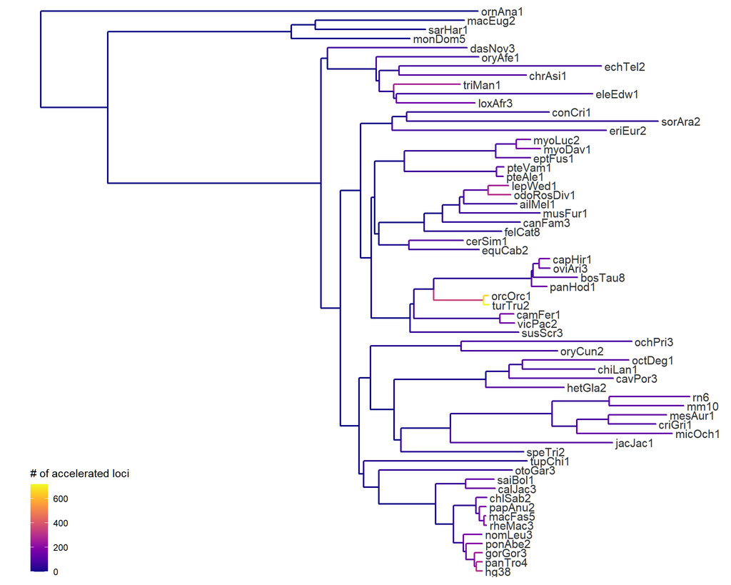

```r
logbf3_cutoff = 4
# The cutoff value for BF3

st_results_m2 = subset(st_results, logbf3 > logbf3_cutoff)
# Getting the loci that favor M2

tree_info$st.m2.count = 0
for(i in 1:nrow(st_results_m2)){
  accel_lineages = st_results_m2[i,]$accel.lineages.m2
  accel_lineages = strsplit(accel_lineages, split=",")[[1]]
  # Split the accelerated lineages into a vector

  for(lineage in accel_lineages){
    tree_info[tree_info$label==lineage,]$st.m2.count = tree_info[tree_info$label==lineage,]$st.m2.count + 1
  }
  # Increment the counts for the accelerated lineages
}
# Counting the number of times each branch is in the accelerated state for loci that favor M2

h = corecol(numcol=1, pal="wilke", offset=3)
l = corecol(numcol=1, offset=3)
# Colors

m2_count_tree = ggtree(tree, size=0.8, ladderize=F, aes(color=tree_info$st.m2.count)) +
  geom_tiplab(color="#333333", size=4) +
  #scale_color_continuous(name='# of acclerated loci', low=l, high=h) +
  scale_color_viridis(name='# of accelerated loci', option = "C") +
  theme(legend.position=c(0.1,0.1))
# Render the tree figure

print(m2_count_tree)
```

```r
# Display the tree figure
```

Here, unsurprisingly given how we sampled these loci, we definitely see an excess of accelerations within the marine mammal lineages. Run the chunk below to see all the branches and their counts.

```r
st_m2_counts = select(tree_info, label, st.m2.count)
st_m2_counts = st_m2_counts[order(-st_m2_counts$st.m2.count), ]
names(st_m2_counts) = c("Branch", "# accelerated loci under M2")
# Select the columns with branch labels and M2 counts and sort

st_m2_counts %>% kable(row.names=F) %>% kable_styling(bootstrap_options=c("striped", "condended", "responsive"), full_width=F) %>%
   scroll_box(width = "100%", height = "20vh")
```

| Branch | # accelerated loci under M2 |
| --- | --- |
| turTru2 | 717 |
| orcOrc1 | 659 |
| turTru2-orcOrc1 | 350 |
| hg38 | 304 |
| odoRosDiv1 | 298 |
| panTro4 | 280 |
| triMan1 | 269 |
| lepWed1 | 259 |
| gorGor3 | 252 |
| rheMac3 | 209 |
| macFas5 | 208 |
| ponAbe2 | 198 |
| hg38-panTro4 | 187 |
| papAnu2 | 183 |
| nomLeu3 | 177 |
| myoDav1 | 175 |
| camFer1 | 171 |
| vicPac2 | 165 |
| capHir1 | 163 |
| myoLuc2 | 161 |
| loxAfr3 | 155 |
| panHod1 | 146 |
| oviAri3 | 146 |
| saiBol1 | 145 |
| calJac3 | 143 |
| rheMac3-macFas5 | 139 |
| pteVam1 | 138 |
| mesAur1 | 137 |
| chlSab2 | 136 |
| micOch1 | 136 |

[output cut: 93 more lines]

```r
# Display the table
```

But does this really tell us that all those loci accelerated in marine mammals are important for living in the ocean? If we took the union of all the accelerated loci in those lineages would their functions all pop-up as being important for changing bone density or increasing body fat? Probably not. In fact a lot of those loci are probably also accelerated in non-marine mammals.

# 8 Using the tree to test hypotheses

So let’s use our phylogeny to setup a test. We really might only be interested in loci that are found to be accelerating ONLY in the ancestral marine mammal lineages. That is those leading to the Pinnipeds, leading to the Cetaceans, and Manatee since that is our only sample from Sirenia. Run the chunk of code to find loci that are accelerated ONLY in those branches:

## 8.1 Ancestral mm accelerations

```r
mm_anc_branches = c("turTru2-orcOrc1", "odoRosDiv1-lepWed1", "triMan1")
# A list of ancestral marine mammal lineages

st_results_m1_m2 = subset(st_results, best.fit.model=="M1" | best.fit.model=="M2")
# Select only loci in which these lineages can be accelerated

st_results_mm_anc = data.frame()
for(i in 1:nrow(st_results_m1_m2)){

  cur_model = tolower(st_results_m1_m2[i,]$best.fit.model)


  accel_lineages = st_results_m1_m2[i,][[paste("accel.lineages.", cur_model, sep="")]]
  accel_lineages = strsplit(accel_lineages, split=",")[[1]]
  # Get the accelerated branches from the current locus

  accel_anc_lineages = intersect(accel_lineages, mm_anc_branches)
  # Get a list of ancestral marine mammal branches that are accelerated in the current locus

  if(setequal(accel_anc_lineages, mm_anc_branches)){
  # Check if the current accelerated ancestral marine mammal branches match the full
  # set of ancestral marine mammal branches

    if(all(accel_lineages %in% mm_branches)){
    # Check if all the accelerated lineages in the current locus are marine mammal lineages

      st_results_mm_anc = rbind(st_results_mm_anc, st_results_m1_m2[i,])
      # Add this locus to the data frame of ancestrally accelerated marine mammal lineages
    }
  }
}
# Count the number of times all three branches are accelerated and no non-marine mammal
# lineages are accelerated

st_results_mm_anc %>% kable() %>% kable_styling(bootstrap_options=c("striped", "condended", "responsive"), full_width=F) %>%
 scroll_box(width = "100%", height = "20vh")
```

|  | phyloacc.id | original.id | best.fit.model | marginal.likelihood.m0 | marginal.likelihood.m1 | marginal.likelihood.m2 | logbf1 | logbf2 | logbf3 | conserved.rate.m0 | accel.rate.m0 | conserved.rate.m1 | accel.rate.m1 | conserved.rate.m2 | accel.rate.m2 | num.accel.m1 | num.accel.m2 | conserved.lineages.m1 | accel.lineages.m1 | conserved.lineages.m2 | accel.lineages.m2 | target.acc |
| --- | --- | --- | --- | --- | --- | --- | --- | --- | --- | --- | --- | --- | --- | --- | --- | --- | --- | --- | --- | --- | --- | --- |
| 624 | 47-23 | chr12-36 | M1 | -2387.8029 | -2378.3372 | -2384.2148 | 9.465704 | 5.877645 | 3.58810 | 0.262000 | 1 | 0.247646 | 0.982105 | 0.244171 | 0.914544 | 7 | 18 | hg38,panTro4,gorGor3,ponAbe2,nomLeu3,rheMac3,macFas5,papAnu2,chlSab2,calJac3,saiBol1,otoGar3,tupChi1,speTri2,jacJac1,micOch1,criGri1,mesAur1,mm10,rn6,hetGla2,cavPor3,chiLan1,octDeg1,oryCun2,ochPri3,su… | turTru2,orcOrc1,odoRosDiv1,lepWed1,triMan1,turTru2-orcOrc1,odoRosDiv1-lepWed1 | hg38,panTro4,gorGor3,ponAbe2,nomLeu3,rheMac3,macFas5,papAnu2,chlSab2,calJac3,saiBol1,tupChi1,speTri2,jacJac1,micOch1,criGri1,mesAur1,mm10,rn6,hetGla2,cavPor3,chiLan1,oryCun2,ochPri3,susScr3,vicPac2,ca… | otoGar3,octDeg1,turTru2,orcOrc1,panHod1,equCab2,cerSim1,odoRosDiv1,lepWed1,pteVam1,loxAfr3,triMan1,chrAsi1,echTel2,turTru2-orcOrc1,equCab2-cerSim1,odoRosDiv1-lepWed1,chrAsi1-echTel2 | Y |
| 1519 | 45-14 | chr15-54 | M1 | -974.5180 | -965.2420 | -969.8454 | 9.276023 | 4.603393 | 4.67263 | 0.339968 | 1 | 0.323370 | 1.719150 | 0.187756 | 0.696753 | 7 | 45 | hg38,panTro4,gorGor3,ponAbe2,nomLeu3,rheMac3,macFas5,papAnu2,chlSab2,calJac3,saiBol1,otoGar3,tupChi1,speTri2,jacJac1,micOch1,criGri1,mesAur1,mm10,rn6,hetGla2,cavPor3,chiLan1,octDeg1,oryCun2,ochPri3,su… | turTru2,orcOrc1,odoRosDiv1,lepWed1,triMan1,turTru2-orcOrc1,odoRosDiv1-lepWed1 | hg38,panTro4,gorGor3,nomLeu3,calJac3,otoGar3,tupChi1,speTri2,criGri1,mm10,rn6,hetGla2,oryCun2,ochPri3,panHod1,bosTau8,oviAri3,capHir1,equCab2,cerSim1,felCat8,canFam3,musFur1,ailMel1,eriEur2,sorAra2,co… | ponAbe2,rheMac3,macFas5,papAnu2,chlSab2,saiBol1,jacJac1,micOch1,mesAur1,cavPor3,chiLan1,octDeg1,susScr3,vicPac2,camFer1,turTru2,orcOrc1,odoRosDiv1,lepWed1,pteAle1,pteVam1,eptFus1,myoDav1,myoLuc2,loxAf… | Y |
| 1653 | 5-23 | chr1-41 | M1 | -625.0636 | -617.7824 | -623.3389 | 7.281256 | 5.556556 | 1.72470 | 0.248346 | 1 | 0.217507 | 1.599330 | 0.221871 | 1.522050 | 7 | 11 | hg38,panTro4,gorGor3,ponAbe2,nomLeu3,rheMac3,macFas5,papAnu2,chlSab2,calJac3,saiBol1,otoGar3,tupChi1,speTri2,jacJac1,micOch1,criGri1,mesAur1,mm10,rn6,hetGla2,cavPor3,chiLan1,octDeg1,oryCun2,ochPri3,su… | turTru2,orcOrc1,odoRosDiv1,lepWed1,triMan1,turTru2-orcOrc1,odoRosDiv1-lepWed1 | hg38,panTro4,gorGor3,ponAbe2,nomLeu3,rheMac3,macFas5,papAnu2,chlSab2,calJac3,saiBol1,otoGar3,tupChi1,speTri2,jacJac1,micOch1,criGri1,mesAur1,mm10,rn6,cavPor3,chiLan1,octDeg1,oryCun2,ochPri3,susScr3,ca… | hetGla2,vicPac2,turTru2,orcOrc1,oviAri3,odoRosDiv1,lepWed1,eptFus1,triMan1,turTru2-orcOrc1,odoRosDiv1-lepWed1 | Y |
| 1934 | 3-4 | chr17-2 | M1 | -2665.0915 | -2660.0267 | -2664.7989 | 5.064842 | 4.772191 | 0.29260 | 0.192891 | 1 | 0.186675 | 0.809024 | 0.188046 | 0.919176 | 7 | 7 | hg38,panTro4,gorGor3,ponAbe2,nomLeu3,rheMac3,macFas5,papAnu2,chlSab2,calJac3,saiBol1,otoGar3,tupChi1,speTri2,jacJac1,micOch1,criGri1,mesAur1,mm10,rn6,hetGla2,cavPor3,chiLan1,octDeg1,oryCun2,ochPri3,su… | turTru2,orcOrc1,odoRosDiv1,lepWed1,triMan1,turTru2-orcOrc1,odoRosDiv1-lepWed1 | hg38,panTro4,gorGor3,ponAbe2,nomLeu3,rheMac3,macFas5,papAnu2,chlSab2,calJac3,saiBol1,otoGar3,tupChi1,speTri2,jacJac1,micOch1,criGri1,mesAur1,mm10,rn6,hetGla2,cavPor3,chiLan1,octDeg1,oryCun2,ochPri3,su… | turTru2,orcOrc1,odoRosDiv1,lepWed1,triMan1,turTru2-orcOrc1,odoRosDiv1-lepWed1 | Y |

```r
# Display a table with the uniquely accelerated ancestral marine mammal loci
```

So we’ve found that among our 2000 loci, out of those that fit M1 or M2, 4 are accelerating in the ancestral marine mammal branches and no where else in the tree (except other marine mammal branches). How does this compare to non-marine mammal lineages?

## 8.2 Control Tree (non-marine mammals)

Run the chunk of code below to display a tree with marine mammal lineages and sister non-marine mammal clades labeled:

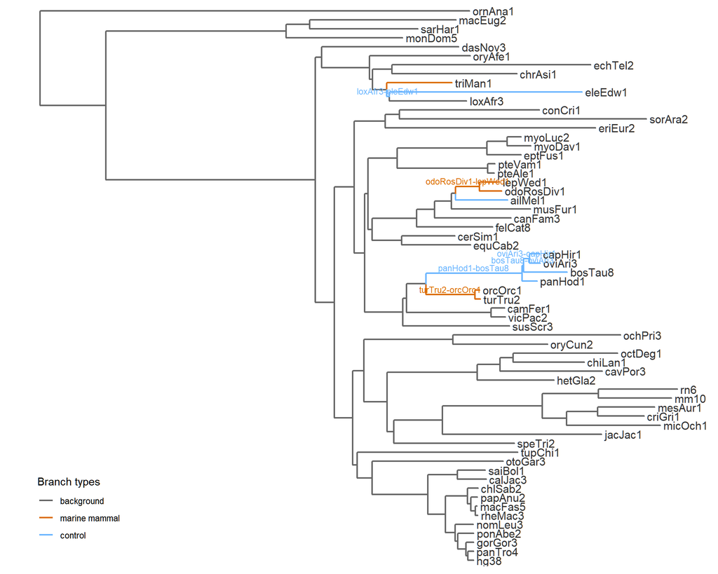

```r
control_branches = c("ailMel1", "loxAfr1", "eleEdw1", "loxAfr3-eleEdw1", "oviAri3", "capHir1", "oviAri3-capHir1", "bosTau8", "bosTau8-oviAri3", "panHod1", "bosTau8-oviAri3", "panHod1-bosTau8")
# A list of control branches sister to marine mammals

tree_info$control = "background"
tree_info[tree_info$label %in% control_branches,]$control = "control"
tree_info[tree_info$label %in% mm_branches,]$control = "marine mammal"
# Label the branches as control, mm, or neither

control_tree = ggtree(tree, size=0.8, ladderize=F, aes(color=tree_info$control)) +
  geom_tiplab(color="#333333", size=4) +
  scale_color_manual(name="Branch types", values=c("background"="#666666", "marine mammal"=corecol(numcol=1), "control"=corecol(numcol=1, offset=5))) +
  geom_text(aes(x=branch, label=ifelse(tree_info$node.type=="internal" & tree_info$control!="background", tree_info$label, '')), size=3, vjust=-0.3, show.legend=F) +
  theme(legend.position=c(0.1,0.1))
# Render the tree figure

print(control_tree)
```

```r
# Display the tree figure
```

So here we can pick out clades sister to marine mammals that don’t share our traits of interest (those relating to living in water) and count the number of accelerated loci found uniquely in their ancestral branches.

```r
control_anc_branches = c("loxAfr3-eleEdw1", "panHod1-bosTau8", "ailMel1")
# A list of ancestral control branches

st_results_m2 = subset(st_results, best.fit.model=="M2")
# Select only those loci where these branches can be accelerated (M2)

st_results_control_anc = data.frame()
for(i in 1:nrow(st_results_m2)){
  accel_lineages = st_results_m2[i,]$accel.lineages.m2
  accel_lineages = strsplit(accel_lineages, split=",")[[1]]
  # Get the accelerated branches from the current locus

  accel_anc_lineages = intersect(accel_lineages, control_anc_branches)
  # Get a list of ancestral control branches that are accelerated in the current locus

  if(setequal(accel_anc_lineages, control_anc_branches)){
    # Check if all the accelerated lineages in the current locus are control lineages

    st_results_control_anc = rbind(st_results_control_anc, st_results_m2[i,])
    # Add this locus to the data frame of ancestrally accelerated control lineages
  }
}
# Count the number of times all three branches are accelerated and no non-marine mammal
# lineages are accelerated

st_results_control_anc %>% kable() %>% kable_styling(bootstrap_options=c("striped", "condended", "responsive"), full_width=F) %>%
 scroll_box(width = "100%", height = "20vh")
```

|  | phyloacc.id | original.id | best.fit.model | marginal.likelihood.m0 | marginal.likelihood.m1 | marginal.likelihood.m2 | logbf1 | logbf2 | logbf3 | conserved.rate.m0 | accel.rate.m0 | conserved.rate.m1 | accel.rate.m1 | conserved.rate.m2 | accel.rate.m2 | num.accel.m1 | num.accel.m2 | conserved.lineages.m1 | accel.lineages.m1 | conserved.lineages.m2 | accel.lineages.m2 | target.acc |
| --- | --- | --- | --- | --- | --- | --- | --- | --- | --- | --- | --- | --- | --- | --- | --- | --- | --- | --- | --- | --- | --- | --- |
| 273 | 20-22 | chr2-70 | M2 | -807.1636 | -792.6662 | -796.1502 | 14.49734 | 3.483969 | 11.01337 | 0.237798 | 1 | 0.219286 | 2.77023 | 0.160588 | 0.688158 | 2 | 38 | hg38,panTro4,gorGor3,ponAbe2,nomLeu3,rheMac3,macFas5,papAnu2,chlSab2,calJac3,saiBol1,otoGar3,tupChi1,speTri2,jacJac1,micOch1,criGri1,mesAur1,mm10,rn6,hetGla2,cavPor3,chiLan1,octDeg1,oryCun2,ochPri3,su… | turTru2,triMan1 | panTro4,nomLeu3,rheMac3,papAnu2,chlSab2,calJac3,saiBol1,otoGar3,tupChi1,speTri2,jacJac1,micOch1,criGri1,mesAur1,mm10,rn6,hetGla2,oryCun2,ochPri3,susScr3,equCab2,cerSim1,felCat8,canFam3,musFur1,pteAle1… | hg38,gorGor3,ponAbe2,macFas5,cavPor3,chiLan1,octDeg1,vicPac2,camFer1,turTru2,orcOrc1,panHod1,bosTau8,oviAri3,capHir1,ailMel1,odoRosDiv1,lepWed1,myoDav1,loxAfr3,eleEdw1,triMan1,chrAsi1,echTel2,chiLan1-… | N |

```r
# Display a table with the uniquely accelerated ancestral control loci
```

Here we find only one locus, so if our question was whether the transition to water led to excessive amounts of convergence… well maybe for this dataset.

## 8.3 Echolocating mammals

But the main point here is that we can use comparative genomics for anything like this. Let’s try the same thing for echolocation:

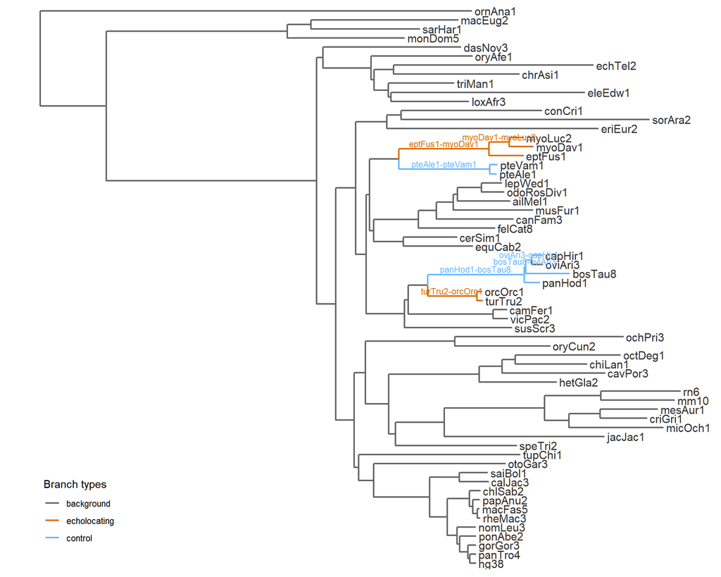

```r
echo_branches = c("turTru2", "orcOrc1", "turTru2-orcOrc1", "myoLuc2", "myoDav1", "myoDav1-myoLuc2", "eptFus1", "eptFus1-myoDav1")
# A list of echolocating mammals

control_branches = c("capHir1", "oviAri3-capHir1", "bosTau8", "bosTau8-oviAri3", "panHod1", "bosTau8-oviAri3", "panHod1-bosTau8", "pteAle1", "pteVam1", "pteAle1-pteVam1")
# A list of control branches sister to echolocating clades

tree_info$control = "background"
tree_info[tree_info$label %in% control_branches,]$control = "control"
tree_info[tree_info$label %in% echo_branches,]$control = "echolocating"
# Label the branches as control, mm, or neither

control_tree = ggtree(tree, size=0.8, ladderize=F, aes(color=tree_info$control)) +
  geom_tiplab(color="#333333", size=4) +
  scale_color_manual(name="Branch types", values=c("background"="#666666", "echolocating"=corecol(numcol=1), "control"=corecol(numcol=1, offset=5))) +
  geom_text(aes(x=branch, label=ifelse(tree_info$node.type=="internal" & tree_info$control!="background", tree_info$label, '')), size=3, vjust=-0.3, show.legend=F) +
  theme(legend.position=c(0.1,0.1))
# Render the tree figure

print(control_tree)
```

```r
# Display the tree figure
```

Run the block below to count the number of loci accelerated in ancestral echolocating lineages:

```r
echo_anc_branches = c("turTru2-orcOrc1", "myoDav1-myoLuc2")
# A list of ancestral echolocating lineages

st_results_m1_m2 = subset(st_results, best.fit.model=="M1" | best.fit.model=="M2")
# Select only loci in which these lineages can be accelerated

st_results_echo_anc = data.frame()
for(i in 1:nrow(st_results_m1_m2)){
  cur_model = tolower(st_results_m1_m2[i,]$best.fit.model)

  accel_lineages = st_results_m1_m2[i,][[paste("accel.lineages.", cur_model, sep="")]]
  accel_lineages = strsplit(accel_lineages, split=",")[[1]]
  # Get the accelerated branches from the current locus

  accel_anc_lineages = intersect(accel_lineages, echo_anc_branches)
  # Get a list of ancestral echolocating branches that are accelerated in the current locus

  if(setequal(accel_anc_lineages, echo_anc_branches)){
  # Check if the current accelerated ancestral echolocating branches match the full
  # set of ancestral mecholocating branches

    if(all(accel_lineages %in% echo_branches)){
    # Check if all the accelerated lineages in the current locus are echolocating lineages

      st_results_echo_anc = rbind(st_results_echo_anc, st_results_m1_m2[i,])
      # Add this locus to the data frame of ancestrally accelerated echolocating lineages
    }
  }
}
# Count the number of times all three branches are accelerated and no non-echolocating
# lineages are accelerated

st_results_echo_anc %>% kable() %>% kable_styling(bootstrap_options=c("striped", "condended", "responsive"), full_width=F) %>%
 scroll_box(width = "100%", height = "20vh")
```

```r
# Display a table with the uniquely accelerated ancestral marine mammal loci
```

And this block in ancestral control lineages:

```r
control_anc_branches = c("panHod1-bosTau8", "pteAle1-pteVam1")
# A list of ancestral control branches

st_results_m2 = subset(st_results, best.fit.model=="M2")
# Select only those loci where these branches can be accelerated (M2)

st_results_control_anc = data.frame()
for(i in 1:nrow(st_results_m2)){
  accel_lineages = st_results_m2[i,]$accel.lineages.m2
  accel_lineages = strsplit(accel_lineages, split=",")[[1]]
  # Get the accelerated branches from the current locus

  accel_anc_lineages = intersect(accel_lineages, control_anc_branches)
  # Get a list of ancestral control branches that are accelerated in the current locus

  if(setequal(accel_anc_lineages, control_anc_branches)){
    # Check if all the accelerated lineages in the current locus are control lineages

    st_results_control_anc = rbind(st_results_control_anc, st_results_m2[i,])
    # Add this locus to the data frame of ancestrally accelerated control lineages
  }
}
# Count the number of times all three branches are accelerated and no non-marine mammal
# lineages are accelerated

st_results_control_anc %>% kable() %>% kable_styling(bootstrap_options=c("striped", "condended", "responsive"), full_width=F) %>%
 scroll_box(width = "100%", height = "20vh")
```

|  | phyloacc.id | original.id | best.fit.model | marginal.likelihood.m0 | marginal.likelihood.m1 | marginal.likelihood.m2 | logbf1 | logbf2 | logbf3 | conserved.rate.m0 | accel.rate.m0 | conserved.rate.m1 | accel.rate.m1 | conserved.rate.m2 | accel.rate.m2 | num.accel.m1 | num.accel.m2 | conserved.lineages.m1 | accel.lineages.m1 | conserved.lineages.m2 | accel.lineages.m2 | target.acc |
| --- | --- | --- | --- | --- | --- | --- | --- | --- | --- | --- | --- | --- | --- | --- | --- | --- | --- | --- | --- | --- | --- | --- |
| 104 | 2-3 | chr13-22 | M2 | -1066.6258 | -1062.6492 | -1061.9929 | 3.976587 | -0.6563537 | 4.63290 | 0.330132 | 1 | 0.318745 | 2.94148 | 0.2472300 | 0.787174 | 2 | 52 | hg38,panTro4,gorGor3,ponAbe2,nomLeu3,rheMac3,macFas5,papAnu2,chlSab2,calJac3,saiBol1,otoGar3,tupChi1,speTri2,jacJac1,micOch1,criGri1,mesAur1,mm10,rn6,hetGla2,cavPor3,chiLan1,octDeg1,oryCun2,ochPri3,su… | orcOrc1,lepWed1 | hg38,panTro4,gorGor3,ponAbe2,nomLeu3,papAnu2,chlSab2,calJac3,otoGar3,tupChi1,speTri2,octDeg1,ochPri3,susScr3,felCat8,canFam3,musFur1,ailMel1,eriEur2,conCri1,loxAfr3,eleEdw1,echTel2,oryAfe1,sarHar1,mac… | rheMac3,macFas5,saiBol1,jacJac1,micOch1,criGri1,mesAur1,mm10,rn6,hetGla2,cavPor3,chiLan1,oryCun2,vicPac2,camFer1,turTru2,orcOrc1,panHod1,bosTau8,oviAri3,capHir1,equCab2,cerSim1,odoRosDiv1,lepWed1,pteA… | N |
| 130 | 52-4 | chr9-81 | M2 | -1421.4281 | -1415.9365 | -1417.2698 | 5.491612 | 1.3332532 | 4.15830 | 0.345120 | 1 | 0.336785 | 3.34672 | 0.2997650 | 0.920750 | 1 | 29 | hg38,panTro4,gorGor3,ponAbe2,nomLeu3,rheMac3,macFas5,papAnu2,chlSab2,calJac3,saiBol1,otoGar3,tupChi1,speTri2,jacJac1,micOch1,criGri1,mesAur1,mm10,rn6,hetGla2,cavPor3,chiLan1,octDeg1,oryCun2,ochPri3,su… | orcOrc1 | ponAbe2,nomLeu3,rheMac3,macFas5,papAnu2,chlSab2,saiBol1,otoGar3,tupChi1,speTri2,criGri1,mesAur1,mm10,rn6,hetGla2,cavPor3,octDeg1,oryCun2,ochPri3,susScr3,vicPac2,camFer1,felCat8,canFam3,musFur1,ailMel1… | hg38,panTro4,gorGor3,calJac3,jacJac1,micOch1,chiLan1,turTru2,orcOrc1,panHod1,bosTau8,oviAri3,capHir1,equCab2,cerSim1,pteAle1,pteVam1,eriEur2,triMan1,dasNov3,hg38-panTro4,hg38-gorGor3,turTru2-orcOrc1,o… | N |
| 182 | 46-6 | chr17-47 | M2 | -2448.5172 | -2435.9808 | -2437.6537 | 12.536393 | 1.6729067 | 10.86350 | 0.379407 | 1 | 0.367521 | 2.04377 | 0.2763060 | 0.647601 | 3 | 42 | hg38,panTro4,gorGor3,ponAbe2,nomLeu3,rheMac3,macFas5,papAnu2,chlSab2,calJac3,saiBol1,otoGar3,tupChi1,speTri2,jacJac1,micOch1,criGri1,mesAur1,mm10,rn6,hetGla2,cavPor3,chiLan1,octDeg1,oryCun2,ochPri3,su… | turTru2,orcOrc1,turTru2-orcOrc1 | hg38,panTro4,gorGor3,nomLeu3,rheMac3,macFas5,papAnu2,chlSab2,calJac3,saiBol1,tupChi1,speTri2,jacJac1,criGri1,mm10,hetGla2,chiLan1,ochPri3,cerSim1,felCat8,canFam3,eriEur2,sorAra2,conCri1,loxAfr3,eleEdw… | ponAbe2,otoGar3,micOch1,mesAur1,rn6,cavPor3,octDeg1,oryCun2,susScr3,vicPac2,camFer1,turTru2,orcOrc1,panHod1,bosTau8,oviAri3,capHir1,equCab2,musFur1,ailMel1,odoRosDiv1,lepWed1,pteAle1,pteVam1,eptFus1,m… | N |
| 538 | 60-12 | chr13-30 | M2 | -1441.0793 | -1433.3586 | -1436.0791 | 7.720728 | 2.7205434 | 5.00020 | 0.337418 | 1 | 0.326281 | 2.75791 | 0.3206460 | 2.387360 | 2 | 42 | hg38,panTro4,gorGor3,ponAbe2,nomLeu3,rheMac3,macFas5,papAnu2,chlSab2,calJac3,saiBol1,otoGar3,tupChi1,speTri2,jacJac1,micOch1,criGri1,mesAur1,mm10,rn6,hetGla2,cavPor3,chiLan1,octDeg1,oryCun2,ochPri3,su… | turTru2,lepWed1 | ponAbe2,nomLeu3,rheMac3,macFas5,papAnu2,chlSab2,calJac3,saiBol1,otoGar3,tupChi1,criGri1,mesAur1,mm10,rn6,hetGla2,cavPor3,chiLan1,equCab2,cerSim1,felCat8,canFam3,ailMel1,odoRosDiv1,sorAra2,conCri1,loxA… | hg38,panTro4,gorGor3,speTri2,jacJac1,micOch1,octDeg1,oryCun2,ochPri3,susScr3,vicPac2,camFer1,turTru2,orcOrc1,panHod1,bosTau8,oviAri3,capHir1,musFur1,lepWed1,pteAle1,pteVam1,eptFus1,myoDav1,myoLuc2,eri… | N |
| 666 | 44-15 | chr7-80 | M2 | -597.0907 | -588.9373 | -591.8141 | 8.153370 | 2.8767616 | 5.27661 | 0.236225 | 1 | 0.219235 | 2.37380 | 0.1347810 | 0.729209 | 3 | 51 | hg38,panTro4,gorGor3,ponAbe2,nomLeu3,rheMac3,macFas5,papAnu2,chlSab2,calJac3,saiBol1,otoGar3,tupChi1,speTri2,jacJac1,micOch1,criGri1,mesAur1,mm10,rn6,hetGla2,cavPor3,chiLan1,octDeg1,oryCun2,ochPri3,su… | turTru2,orcOrc1,turTru2-orcOrc1 | calJac3,saiBol1,otoGar3,tupChi1,speTri2,jacJac1,mm10,rn6,chiLan1,susScr3,vicPac2,camFer1,felCat8,canFam3,musFur1,ailMel1,lepWed1,myoLuc2,eriEur2,sorAra2,loxAfr3,eleEdw1,triMan1,dasNov3,monDom5,sarHar1… | hg38,panTro4,gorGor3,ponAbe2,nomLeu3,rheMac3,macFas5,papAnu2,chlSab2,micOch1,criGri1,mesAur1,hetGla2,cavPor3,octDeg1,oryCun2,ochPri3,turTru2,orcOrc1,panHod1,bosTau8,oviAri3,capHir1,equCab2,cerSim1,odo… | N |
| 782 | 4-6 | chr4-3 | M2 | -1277.9529 | -1268.1974 | -1272.1686 | 9.755546 | 3.9712812 | 5.78430 | 0.400196 | 1 | 0.386636 | 4.41391 | 0.3865860 | 4.224090 | 1 | 33 | hg38,panTro4,gorGor3,ponAbe2,nomLeu3,rheMac3,macFas5,papAnu2,chlSab2,calJac3,saiBol1,otoGar3,tupChi1,speTri2,jacJac1,micOch1,criGri1,mesAur1,mm10,rn6,hetGla2,cavPor3,chiLan1,octDeg1,oryCun2,ochPri3,su… | turTru2 | macFas5,papAnu2,chlSab2,otoGar3,tupChi1,speTri2,micOch1,criGri1,mesAur1,rn6,hetGla2,octDeg1,oryCun2,ochPri3,susScr3,vicPac2,camFer1,equCab2,cerSim1,felCat8,canFam3,musFur1,ailMel1,odoRosDiv1,lepWed1,e… | hg38,panTro4,gorGor3,ponAbe2,nomLeu3,rheMac3,calJac3,saiBol1,jacJac1,mm10,cavPor3,chiLan1,turTru2,orcOrc1,panHod1,bosTau8,oviAri3,capHir1,pteAle1,pteVam1,eriEur2,conCri1,loxAfr3,oryAfe1,hg38-panTro4,h… | N |
| 956 | 8-5 | chr1-228 | M2 | -1542.5443 | -1530.6012 | -1533.7637 | 11.943068 | 3.1624691 | 8.78060 | 0.396592 | 1 | 0.384598 | 4.78439 | 0.3528940 | 1.714020 | 1 | 67 | hg38,panTro4,gorGor3,ponAbe2,nomLeu3,rheMac3,macFas5,papAnu2,chlSab2,calJac3,saiBol1,otoGar3,tupChi1,speTri2,jacJac1,micOch1,criGri1,mesAur1,mm10,rn6,hetGla2,cavPor3,chiLan1,octDeg1,oryCun2,ochPri3,su… | orcOrc1 | speTri2,jacJac1,micOch1,mm10,hetGla2,vicPac2,canFam3,musFur1,eptFus1,sorAra2,conCri1,eleEdw1,triMan1,chrAsi1,oryAfe1,monDom5,sarHar1,macEug2,ornAna1,micOch1-criGri1,mm10-rn6,micOch1-mm10,jacJac1-micOc… | hg38,panTro4,gorGor3,ponAbe2,nomLeu3,rheMac3,macFas5,papAnu2,chlSab2,calJac3,saiBol1,otoGar3,tupChi1,criGri1,mesAur1,rn6,cavPor3,chiLan1,octDeg1,oryCun2,ochPri3,susScr3,camFer1,turTru2,orcOrc1,panHod1… | N |
| 1788 | 80-8 | chr4-56 | M2 | -818.4750 | -809.6101 | -813.4801 | 8.864925 | 3.8700204 | 4.99490 | 0.343061 | 1 | 0.321917 | 4.19706 | 0.3135820 | 3.763280 | 1 | 41 | hg38,panTro4,gorGor3,ponAbe2,nomLeu3,rheMac3,macFas5,papAnu2,chlSab2,calJac3,saiBol1,otoGar3,tupChi1,speTri2,jacJac1,micOch1,criGri1,mesAur1,mm10,rn6,hetGla2,cavPor3,chiLan1,octDeg1,oryCun2,ochPri3,su… | turTru2 | gorGor3,ponAbe2,nomLeu3,papAnu2,chlSab2,saiBol1,otoGar3,tupChi1,micOch1,criGri1,mesAur1,cavPor3,oryCun2,ochPri3,susScr3,vicPac2,camFer1,equCab2,cerSim1,felCat8,canFam3,musFur1,ailMel1,lepWed1,sorAra2,… | hg38,panTro4,rheMac3,macFas5,calJac3,speTri2,jacJac1,mm10,rn6,hetGla2,chiLan1,octDeg1,turTru2,orcOrc1,panHod1,bosTau8,oviAri3,capHir1,odoRosDiv1,pteAle1,pteVam1,eptFus1,myoDav1,myoLuc2,eriEur2,eleEdw1… | N |
| 1929 | 15-24 | chr10-1 | M2 | -369.4758 | -360.8030 | -363.2309 | 8.672787 | 2.4278907 | 6.24490 | 0.116157 | 1 | 0.104292 | 3.24153 | 0.0733599 | 0.767665 | 2 | 26 | hg38,panTro4,gorGor3,ponAbe2,nomLeu3,rheMac3,macFas5,papAnu2,chlSab2,calJac3,saiBol1,otoGar3,tupChi1,speTri2,jacJac1,micOch1,criGri1,mesAur1,mm10,rn6,hetGla2,cavPor3,chiLan1,octDeg1,oryCun2,ochPri3,su… | orcOrc1,lepWed1 | hg38,gorGor3,ponAbe2,nomLeu3,papAnu2,chlSab2,calJac3,saiBol1,tupChi1,speTri2,jacJac1,micOch1,criGri1,mesAur1,mm10,rn6,hetGla2,cavPor3,chiLan1,octDeg1,oryCun2,ochPri3,vicPac2,camFer1,turTru2,equCab2,ce… | panTro4,rheMac3,macFas5,otoGar3,susScr3,orcOrc1,panHod1,bosTau8,oviAri3,capHir1,lepWed1,pteAle1,pteVam1,myoDav1,myoLuc2,loxAfr3,eleEdw1,triMan1,rheMac3-macFas5,oviAri3-capHir1,bosTau8-oviAri3,panHod1-… | N |

```r
# Display a table with the uniquely accelerated ancestral control loci
```

So this time, we don’t see any excess of acceleration associated with echolocation. This is very consistent with previous results (but still not the whole dataset).

# 9 Phylogenetic discordance

Discordance among the phylogenies inferred from different locations in the genome, and discordance between locus phylogenies and the inferred species tree, is known as phylogenetic discordance. Phylogenetic discordance can be caused by a variety of processes:

1. Ancestral polymorphism persisting after speciation followed by recombination leads to **incomplete lineage sorting**
2. Hybridization that results in **introgression** of loci from one lineage to another followed by recombination
3. Gene duplication and subsequent loss can results in **hidden paralogy**
4. Technical error

See [Maddison 1997](https://doi.org/10.1093/sysbio/46.3.523) for a great intro to phylogenetic discordance, [Edwards 2009](https://doi.org/10.1111/j.1558-5646.2008.00549.x) for an in depth consideration of the effects of phylogenetic discordance, and [Hahn & Nakhleh 2015](https://doi.org/10.1111/evo.12832) for an example of how discordance can affect inferences (in bats!).

When estimating substitution rates, the use of a single species tree on alignments from loci that have a different phylogeny results in the mis-mapping of substitutions and the mis-inference of rates [Mendes & Hahn 2016](https://doi.org/10.1093/sysbio/syw018). Downstream affects could include spurious inferences of rate acceleration or positive selection. PhyloAcc’s gene tree model accounts for discordance caused by **incomplete lineage sorting** by sampling phylogenies for each locus and then estimating rates.

But what practical effect does this have on results?

## 9.1 Quantifying discordance

The PhyloAcc pipeline now quantifies discordance using **site concordance factors (sCF)**. That is, for each locus it counts the number of sites that support the topology by sampling quartets around internal branches. For a branch $x$ with a sampled quartet $q$, the concordance factor would be:

$$sCF_q(x) = \frac{|\{ \text{site} : \text{site is concordant with } x \}}{|\{ \text{site} : \text{site is decisive for } x \}}$$

We sample many quartets and average them together and then use the concordance factors to decide which model to run the locus with, the species tree model or the gene tree method.

Run this block of code to display average site concordance factors across all loci:

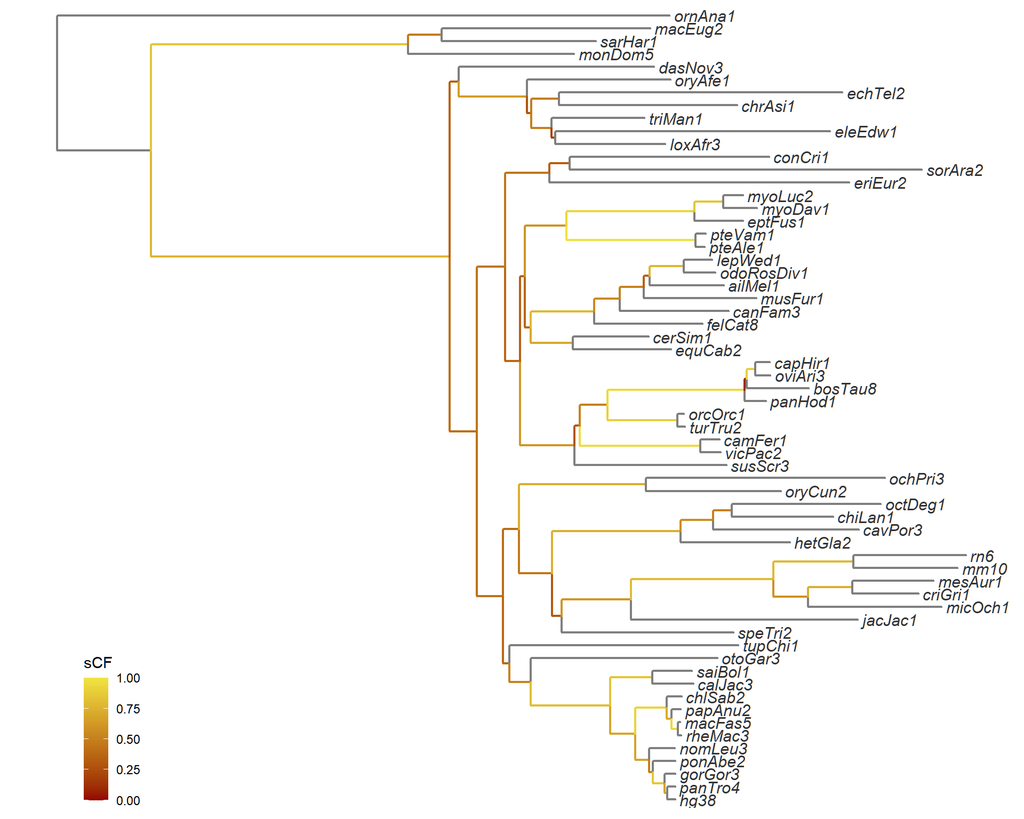

```r
h = corecol(numcol=1, pal="wilke", offset=3)
l = corecol(numcol=1, offset=3)
# Colors

scf_tree_fig = ggtree(scf_tree, size=0.8, ladderize=F, aes(color=scf_tree_info$scf)) +
  scale_color_continuous(name='sCF', low=l, high=h, limits=c(0,1)) +
  geom_tiplab(color="#333333", fontface='italic', size=4) +
  theme(legend.position=c(0.1,0.1))
# Render the tree figure

print(scf_tree_fig)
```

```r
# Display the tree figure
```

This tree shows concordance factors averaged across all loci. PhyloAcc also calculates concordance factors individually for each locus and averages them across all branches:

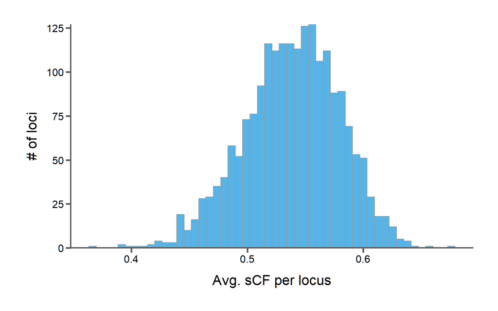

```r
scf_dist = ggplot(data=aln_stats, aes(x=node.scf.avg)) +
  geom_histogram(bins=50, fill=corecol(pal="wilke", numcol=1, offset=1), color="#999999") +
  scale_y_continuous(expand=c(0,0)) +
  xlab("Avg. sCF per locus") +
  ylab("# of loci") +
  bartheme()

print(scf_dist)
```

This tells us that for many loci, average sCF is above 0.5, meaning more than 50% of sites support the species tree topology.

## 9.2 Effects of discordance on PhyloAcc results

We can compare loci run through both the species tree and gene tree models. Here we will take one locus with high sCF and one with low to see how the different models affect inference:

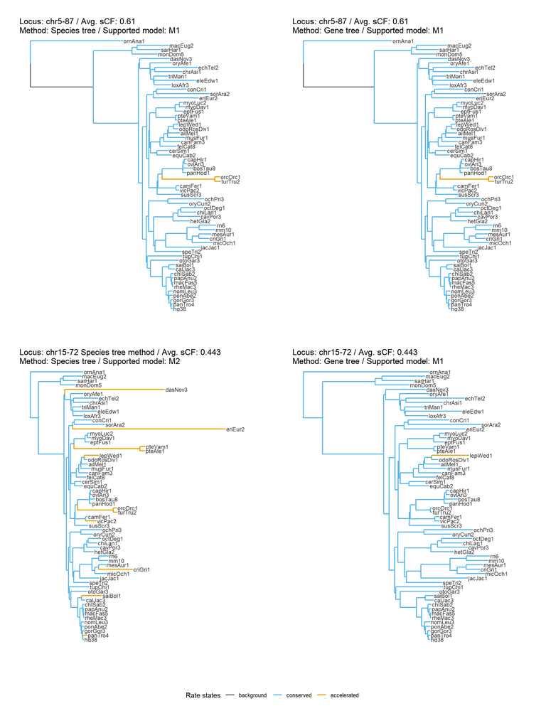

```r
scf_data = select(aln_stats, locus, node.scf.avg)
names(scf_data)[1] = "original.id"

all_results = merge(st_results, gt_results, by="original.id", suffixes=c(".st", ".gt"))
all_results = merge(all_results, scf_data, by="original.id")

st_results_high = subset(all_results, node.scf.avg > 0.6)
st_results_high = subset(st_results_high, best.fit.model.st == best.fit.model.gt)
st_results_high = subset(st_results_high, best.fit.model.st != "M0" & best.fit.model.gt != "M0")

high_locus = sample_n(st_results_high, 1)
# This randomly selects a locus with high sCF where the best fit models match between
# gene and species tree methods

high_locus = subset(st_results_high, original.id=="chr5-87")
# Select an M1 locus as an example. Other good ones are: chr5-87

high_st_model = tolower(high_locus$best.fit.model.st)
high_gt_model = tolower(high_locus$best.fit.model.gt)

## Selecting locus with high sCF
##########

st_results_low = subset(all_results, node.scf.avg < 0.45)
st_results_low = subset(st_results_low, best.fit.model.st != best.fit.model.gt)
st_results_low = subset(st_results_low, best.fit.model.st != "M0" & best.fit.model.gt != "M0")

#low_locus = sample_n(st_results_low, 1)
# This randomly selects a locus with low sCF where the best fit models don't match between
# gene and species tree methods

low_locus = subset(st_results_low, original.id=="chr15-72")
# Select an M1 locus as an example. Other good ones are: chr15-72, chr1-11

low_st_model = tolower(low_locus$best.fit.model.st)
low_gt_model = tolower(low_locus$best.fit.model.gt)

## Selecting locus with LOW sCF
##########

con_high_st = strsplit(high_locus[[paste("conserved.lineages.", high_st_model, ".st" , sep="")]], split=",")[[1]]
acc_high_st = strsplit(high_locus[[paste("accel.lineages.", high_st_model, ".st", sep="")]], split=",")[[1]]
# HIGH SCF ST

con_high_gt = strsplit(high_locus[[paste("conserved.lineages.", high_gt_model, ".gt", sep="")]], split=",")[[1]]
acc_high_gt = strsplit(high_locus[[paste("accel.lineages.", high_gt_model, ".gt", sep="")]], split=",")[[1]]
# HIGH SCF GT

con_low_st = strsplit(low_locus[[paste("conserved.lineages.", low_st_model, ".st" , sep="")]], split=",")[[1]]
acc_low_st = strsplit(low_locus[[paste("accel.lineages.", low_st_model, ".st" , sep="")]], split=",")[[1]]
# LOW SCF ST

con_low_gt = strsplit(low_locus[[paste("conserved.lineages.", low_gt_model, ".gt", sep="")]], split=",")[[1]]
acc_low_gt = strsplit(low_locus[[paste("accel.lineages.", low_gt_model, ".gt", sep="")]], split=",")[[1]]
# LOW SCF GT

## Split the lineages in each state for both M1 and M2 into vectors
##########

tree_info$high.state.st = "background"
tree_info[tree_info$label %in% acc_high_st,]$high.state.st = "accelerated"
tree_info[tree_info$label %in% con_high_st,]$high.state.st = "conserved"
# HIGH SCF ST

tree_info$high.state.gt = "background"
tree_info[tree_info$label %in% acc_high_gt,]$high.state.gt = "accelerated"
tree_info[tree_info$label %in% con_high_gt,]$high.state.gt = "conserved"
# HIGH SCF GT

tree_info$low.state.st = "background"
tree_info[tree_info$label %in% acc_low_st,]$low.state.st = "accelerated"
tree_info[tree_info$label %in% con_low_st,]$low.state.st = "conserved"
# LOW SCF ST

tree_info$low.state.gt = "background"
tree_info[tree_info$label %in% acc_low_gt,]$low.state.gt = "accelerated"
tree_info[tree_info$label %in% con_low_gt,]$low.state.gt = "conserved"
# LOW SCF GT

# Label each branch in the tree as background, accelerated, or conserved for the best fitting model
##########

tree_info$high.bl.st = tree_info$branch.length
tree_info[tree_info$label %in% con_high_st,]$high.bl.st = tree_info[tree_info$label %in% con_high_st,]$high.bl.st * high_locus[[paste("conserved.rate.", low_st_model, ".st" , sep="")]]
tree_info[tree_info$label %in% acc_high_st,]$high.bl.st = tree_info[tree_info$label %in% acc_high_st,]$high.bl.st * high_locus[[paste("accel.rate.", low_st_model, ".st" , sep="")]]
# HIGH SCF ST

tree_info$high.bl.gt = tree_info$branch.length
tree_info[tree_info$label %in% con_high_gt,]$high.bl.gt = tree_info[tree_info$label %in% con_high_gt,]$high.bl.gt * high_locus[[paste("conserved.rate.", low_st_model, ".gt" , sep="")]]
tree_info[tree_info$label %in% acc_high_gt,]$high.bl.gt = tree_info[tree_info$label %in% acc_high_gt,]$high.bl.gt * high_locus[[paste("accel.rate.", low_st_model, ".gt" , sep="")]]
# HIGH SCF GT

tree_info$low.bl.st = tree_info$branch.length
tree_info[tree_info$label %in% con_low_st,]$low.bl.st = tree_info[tree_info$label %in% con_low_st,]$low.bl.st * low_locus[[paste("conserved.rate.", low_st_model, ".st" , sep="")]]
tree_info[tree_info$label %in% acc_low_st,]$low.bl.st = tree_info[tree_info$label %in% acc_low_st,]$low.bl.st * low_locus[[paste("accel.rate.", low_st_model, ".st" , sep="")]]
# LOW SCF ST

tree_info$low.bl.gt = tree_info$branch.length
tree_info[tree_info$label %in% con_low_gt,]$low.bl.gt = tree_info[tree_info$label %in% con_low_gt,]$low.bl.gt * low_locus[[paste("conserved.rate.", low_st_model, ".gt" , sep="")]]
tree_info[tree_info$label %in% acc_low_gt,]$low.bl.gt = tree_info[tree_info$label %in% acc_low_gt,]$low.bl.gt * low_locus[[paste("accel.rate.", low_st_model, ".gt" , sep="")]]
# LOW SCF GT

# M1 LOCUS:  Adjust branch lengths based on the substitution rates in the best fitting model
##########

high_st_tree = tree
high_gt_tree = tree
low_st_tree = tree
low_gt_tree = tree

for(i in 1:length(tree$edge.length)){
  cur_len = tree$edge.length[i]
  cur_len = format(round(cur_len, 8), nsmall=8)
  # Get the original length for this branch and convert it to a rounded string

  if(!tree_info[format(round(tree_info$branch.length,8), nsmall=8)==cur_len,]$high.state.st == "background"){
    high_st_tree$edge.length[i] = tree_info[format(round(tree_info$branch.length,8), nsmall=8)==cur_len,]$high.bl.st
  }
  # HIGH SCF ST

  if(!tree_info[format(round(tree_info$branch.length,8), nsmall=8)==cur_len,]$high.state.gt == "background"){
    high_gt_tree$edge.length[i] = tree_info[format(round(tree_info$branch.length,8), nsmall=8)==cur_len,]$high.bl.gt
  }
  # HIGH SCF GT

  if(!tree_info[format(round(tree_info$branch.length,8), nsmall=8)==cur_len,]$low.state.st == "background"){
    low_st_tree$edge.length[i] = tree_info[format(round(tree_info$branch.length,8), nsmall=8)==cur_len,]$low.bl.st
  }
  # LOW SCF ST

  if(!tree_info[format(round(tree_info$branch.length,8), nsmall=8)==cur_len,]$low.state.gt == "background"){
    low_gt_tree$edge.length[i] = tree_info[format(round(tree_info$branch.length,8), nsmall=8)==cur_len,]$low.bl.gt
  }
  # LOW SCF GT

}
# Loop over every branch in the tree and adjust the branch length based on the state in the model

####################

cols = c("background"="#666666", "conserved"=corecol(numcol=1, pal="wilke", offset=1), "accelerated"=corecol(numcol=1, pal="wilke"))
# Set colors for conservation states

cur_title = paste("Locus: ", high_locus$original.id, " / Avg. sCF: ", round(high_locus$node.scf.avg,3), "\nMethod: Species tree / Supported model: ", high_locus$best.fit.model.st, sep="")
xmax = max(nodeHeights(high_st_tree)) + sd(nodeHeights(high_st_tree))
high_st_tree_fig = ggtree(high_st_tree, size=0.8, ladderize=F, aes(color=tree_info$high.state.st)) +
  geom_tiplab(color="#333333", size=3.2) +
  xlim(0, xmax) +
  scale_color_manual(name="Rate states", values=cols) +
  #geom_text(aes(x=branch, label=ifelse(tree_info$node.type=="internal" & tree_info$mm=="Y", tree_info$label, '')), size=3, vjust=-0.3, show.legend=F) +
  ggtitle(cur_title) +
  theme(legend.position="bottom",
        plot.margin=unit(c(1,1,1,1), "cm"))
# HIGH SCF ST tree

cur_title = paste("Locus: ", high_locus$original.id, " / Avg. sCF: ", round(high_locus$node.scf.avg,3), "\nMethod: Gene tree / Supported model: ", high_locus$best.fit.model.gt, sep="")
xmax = max(nodeHeights(high_gt_tree)) + sd(nodeHeights(high_gt_tree))
high_gt_tree_fig = ggtree(high_gt_tree, size=0.8, ladderize=F, aes(color=tree_info$high.state.gt)) +
  geom_tiplab(color="#333333", size=3.2) +
  xlim(0, xmax) +
  scale_color_manual(name="Rate states", values=cols) +
  #geom_text(aes(x=branch, label=ifelse(tree_info$node.type=="internal" & tree_info$mm=="Y", tree_info$label, '')), size=3, vjust=-0.3, show.legend=F) +
  ggtitle(cur_title) +
  theme(legend.position="bottom",
        plot.margin=unit(c(1,1,1,1), "cm"))
# HIGH SCF GT tree

cur_title = paste("Locus: ", low_locus$original.id, " Species tree method / Avg. sCF: ", round(low_locus$node.scf.avg,3), "\nMethod: Species tree / Supported model: ", low_locus$best.fit.model.st, sep="")
xmax = max(nodeHeights(low_st_tree)) + sd(nodeHeights(low_st_tree))
low_st_tree_fig = ggtree(low_st_tree, size=0.8, ladderize=F, aes(color=tree_info$low.state.st)) +
  geom_tiplab(color="#333333", size=3.2) +
  xlim(0, xmax) +
  scale_color_manual(name="Rate states", values=cols) +
  #geom_text(aes(x=branch, label=ifelse(tree_info$node.type=="internal" & tree_info$mm=="Y", tree_info$label, '')), size=3, vjust=-0.3, show.legend=F) +
  ggtitle(cur_title) +
  theme(legend.position="bottom",
        plot.margin=unit(c(1,1,1,1), "cm"))
# LOW SCF ST tree

cur_title = paste("Locus: ", low_locus$original.id, " / Avg. sCF: ", round(low_locus$node.scf.avg,3), "\nMethod: Gene tree / Supported model: ", low_locus$best.fit.model.gt, sep="")
xmax = max(nodeHeights(low_gt_tree)) + sd(nodeHeights(low_gt_tree))
low_gt_tree_fig = ggtree(low_gt_tree, size=0.8, ladderize=F, aes(color=tree_info$low.state.gt)) +
  geom_tiplab(color="#333333", size=3.2) +
  xlim(0, xmax) +
  scale_color_manual(name="Rate states", values=cols) +
  #geom_text(aes(x=branch, label=ifelse(tree_info$node.type=="internal" & tree_info$mm=="Y", tree_info$label, '')), size=3, vjust=-0.3, show.legend=F) +
  ggtitle(cur_title) +
  theme(legend.position="bottom",
        plot.margin=unit(c(1,1,1,1), "cm"))
# LOW SCF GT tree

tree_legend = get_legend(high_st_tree_fig)
# Get the legend from one fig

tree_fig_top = plot_grid(high_st_tree_fig + theme(legend.position="none"),
                     high_gt_tree_fig + theme(legend.position="none"),
                     low_st_tree_fig + theme(legend.position="none"),
                     low_gt_tree_fig + theme(legend.position="none"),
                     ncol=2)
# Combine the M1 locus trees into a single row, removing individual legends

tree_fig = plot_grid(tree_fig_top, tree_legend, nrow=2, rel_heights=c(1,0.1))
# Combine the M1 locus row, M2 locus row, and a single legend

print(tree_fig)
```

```r
# Display the figure
```

The two trees in the top row have an sCF near the top of our distribution. On the left is the result (rates and states) of running this locus with the species tree model and on the right is the same with the gene tree model. We can see that both methods say that M1 (acceleration in target lineages only) best fits the data and the states don’t change. Only cetaceans are accelerated in both runs. This means that phylogenetic discordance between the locus tree and the species tree does not affect inferences for this locus.

On the bottom, we show another locus from the low end of the sCF distribution. Again, on the left is the run with the species tree method and on the right with the gene tree method. In this case, the best fitting model changes between the two. When not considering discordance (left), M2 is the best fitting model and many branches are inferred to be accelerated. However, with the gene tree method, M1 is the best fitting model and only the Weddell seal is inferred to have accelerated substitution rates. In this case, the phylogeny underlying the locus likely differs from the species tree topology substantially, resulting in substitutions being mis-counted when they are placed on the species tree. Here the gene tree model corrects for this, resulting in a more accurate estimation of rates and states.

# 10 The end

If you see a “Knit” button above the window containing the code you can compile this document to an HTML page and save it with all figures generated. To do so, click on the “Knit” button above the text editor!

Thanks for your attention!